# Examen año 2022

Jose Valdes

2023-07-12

```r
#limpio la memoria
rm( list= ls(all.names= TRUE) )  #remove all objects
gc( full= TRUE )                 #garbage collection
```

```
##          used (Mb) gc trigger (Mb) max used (Mb)
## Ncells 512223 27.4    1141371   61   644245 34.5
## Vcells 933078  7.2    8388608   64  1635140 12.5
```

Se realiza validación de la instalación de los paquetes necesarios para ejecutar el script

```r
# Bibliotecas a cargar

check_packages <- function(packages) {
  if (all(packages %in% rownames(installed.packages()))) {
    TRUE
  } else{
    cat(
      "Instalar los siguientes packages antes de ejecutar el presente script\n",
      packages[!(packages %in% rownames(installed.packages()))],
      "\n"
    )
  }
}
packages_needed <- c("readxl","ggplot2","MVN","gridExtra","aod","MASS","carData","car","robustbase","leaps","olsrr","gamlss","lsr","ggpubr","lmtest","ResourceSelection","vcd","pROC","ROCR")

# Se llama a la funcion check_packages
check_packages(packages_needed)
```

```
## [1] TRUE
```

```r
library(readxl)
library(ggplot2)
library(MVN)
library(gridExtra)
library(aod)
library(MASS)
library(carData)
library(car)
library(robustbase)
library(leaps)
library(olsrr)
library(gamlss)
library(lsr)
library(ggpubr)
library(lmtest)
library(ResourceSelection)
```

```
## ResourceSelection 0.3-6   2023-06-27
```

```r
library(vcd)
library(pROC)
library(ROCR)
```

# Ejercicio 1

En el archivo preciocasas.xlsx se han registrado respecto de 100 viviendas las siguientes variables: • impuestos: valor de impuesto anual de la vivienda. • dormitorios cantidad de ambientes de la vivienda. • banios: cantidad de baños del inmueble. • estrena: si es a estrenar. • precio: valor del alquiler de la vivienda • tamanio: superficie total de la vivienda.

```r
library(readxl)
preciocasas<-read_excel("C:/Users/Josvaldes/Documents/Maestria/Austral/1ano/regresionAvanzada/TPRegresion/TPRegresion/examen/prueba/preciocasas.xlsx")
preciocasas
```

| caso | impuestos | dormitorios | banios | estrena | precio | tamanio |
| --- | --- | --- | --- | --- | --- | --- |
| 1 | 3104 | 4 | 2 | 0 | 279900 | 2048 |
| 2 | 1173 | 2 | 1 | 0 | 146500 | 912 |
| 3 | 3076 | 4 | 2 | 0 | 237700 | 1654 |
| 4 | 1608 | 3 | 2 | 0 | 200000 | 2068 |
| 5 | 1454 | 3 | 3 | 0 | 159900 | 1477 |
| 6 | 2997 | 3 | 2 | 1 | 499900 | 3153 |
| 7 | 4054 | 3 | 2 | 0 | 265500 | 1355 |
| 8 | 3002 | 3 | 2 | 1 | 289900 | 2075 |
| 9 | 6627 | 5 | 4 | 0 | 587000 | 3990 |
| 10 | 680 | 2 | 1 | 0 | 142500 | 1170 |

[output cut: 90 more lines]

Se observa la distrubución a través de un grafico:

Diagrama de dispersión

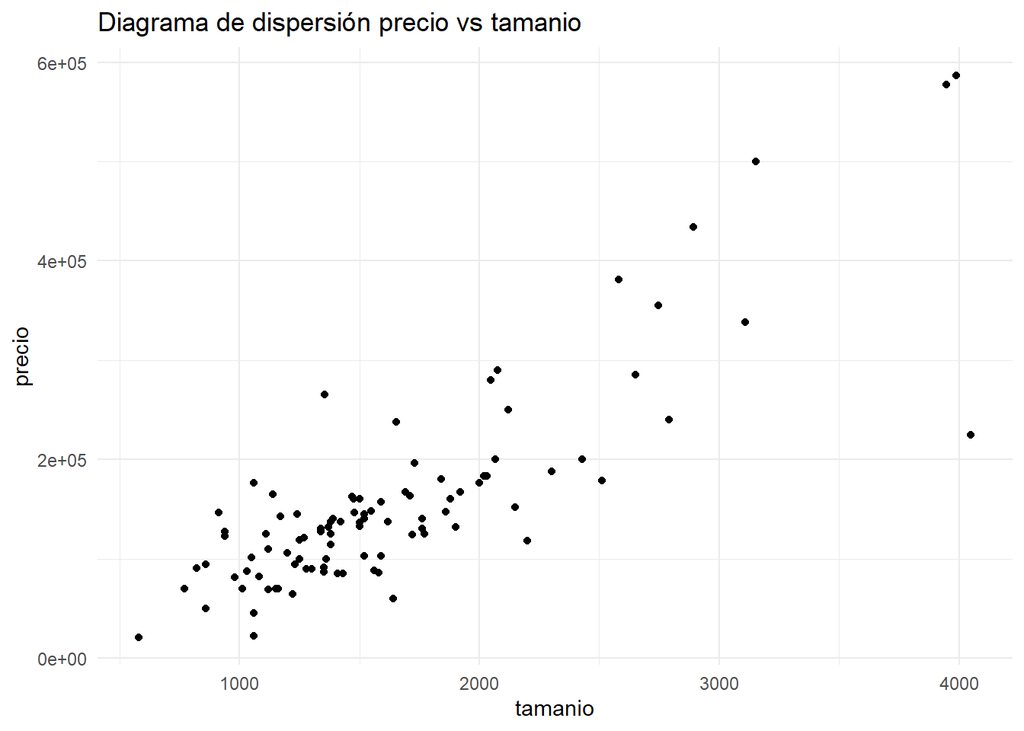

```r
library(ggplot2)
#Diagrama de dispersión precio en función del tamanio
dd1=ggplot(preciocasas, aes(tamanio, precio)) +
  geom_point() + theme_minimal() + labs(title = "Diagrama de dispersi\u00F3n precio vs tamanio")
dd1
```

Por la distribución de los datos se creeria que se podria realizar un ajuste lineal.

## 1. Construir un modelo lineal simple para explicar el precio en función de la superficie y evaluar la bondad del ajuste.

```r
modeleje1= lm(precio ~ tamanio, data = preciocasas )
summary(modeleje1)
```

```
##
## Call:
## lm(formula = precio ~ tamanio, data = preciocasas)
##
## Residuals:
##     Min      1Q  Median      3Q     Max
## -236780  -29552   -2507   21639  151675
##
## Coefficients:
##               Estimate Std. Error t value Pr(>|t|)
## (Intercept) -50926.255  14896.373  -3.419 0.000918 ***
## tamanio        126.594      8.468  14.951  < 2e-16 ***
## ---
## Signif. codes:  0 '***' 0.001 '**' 0.01 '*' 0.05 '.' 0.1 ' ' 1
##
## Residual standard error: 56190 on 98 degrees of freedom
## Multiple R-squared:  0.6952, Adjusted R-squared:  0.6921
## F-statistic: 223.5 on 1 and 98 DF,  p-value: < 2.2e-16
```

- El intercepto (constante) tiene una estimación de -50926.255 y es significativamente diferente de cero, lo que indica que hay un valor base en el precio que no depende del tamaño.
- La variable “tamanio” tiene una estimación de 126.594, lo que significa que por cada unidad de aumento en el tamaño, se espera un aumento de 126.594 en el precio.
- Ambos coeficientes (intercepto y tamanio) son estadísticamente significativos, ya que los valores p son muy pequeños (<0.001).
- El coeficiente de determinación (R-cuadrado) es 0.6952, lo que indica que aproximadamente el 69.52% de la variabilidad en el precio se explica por el modelo.
- El error estándar residual es 56190, lo que indica la dispersión promedio de los residuos alrededor de la línea de regresión.
- El valor F es 223.5 con un valor p muy pequeño (<2.2e-16), lo que indica que el modelo es estadísticamente significativo y hay una relación lineal entre el tamaño y el precio.

## 2. Realizar un análisis diagnóstico y de puntos influyentes e indicar si el modelo es adecuado.

Análisis diagnóstico -Normalidad

```r
shapiro.test(preciocasas$tamanio)
```

```
##
##  Shapiro-Wilk normality test
##
## data:  preciocasas$tamanio
## W = 0.85564, p-value = 1.928e-08
```

Se rechaza normalidad de la variable tamanio.

```r
shapiro.test(preciocasas$precio)
```

```
##
##  Shapiro-Wilk normality test
##
## data:  preciocasas$precio
## W = 0.7658, p-value = 2.502e-11
```

Análisis de normalidad multivariada - Test de Henze Zirkler

```r
#Analizamos normalidad bivariada
library(MVN)
#Usamos Test Henze-Zirkler para evaluar normalidad multivariada (bivariada en este caso)
respuesta_testHZ<-mvn(preciocasas , mvnTest = "hz")
respuesta_testHZ
```

```
## $multivariateNormality
##            Test       HZ p value MVN
## 1 Henze-Zirkler 2.825519       0  NO
##
## $univariateNormality
##               Test    Variable Statistic   p value Normality
## 1 Anderson-Darling    caso        1.0837  0.0073      NO
## 2 Anderson-Darling  impuestos     3.0879  <0.001      NO
## 3 Anderson-Darling dormitorios   10.8888  <0.001      NO
## 4 Anderson-Darling   banios      14.2875  <0.001      NO
## 5 Anderson-Darling   estrena     32.1905  <0.001      NO
## 6 Anderson-Darling   precio       6.6582  <0.001      NO
## 7 Anderson-Darling   tamanio      3.9940  <0.001      NO
##
## $Descriptives
##               n      Mean      Std.Dev   Median   Min    Max     25th      75th
## caso        100     50.50 2.901149e+01     50.5     1    100    25.75     75.25
## impuestos   100   1908.39 1.235826e+03   1614.0    20   6627  1178.25   2237.50
## dormitorios 100      3.00 6.513389e-01      3.0     2      5     3.00      3.00
## banios      100      1.96 5.671121e-01      2.0     1      4     2.00      2.00
## estrena     100      0.11 3.144660e-01      0.0     0      1     0.00      0.00
## precio      100 155331.00 1.012622e+05 132600.0 21000 587000 93225.00 169625.00
## tamanio     100   1629.28 6.669417e+02   1473.5   580   4050  1215.00   1865.00
##                  Skew   Kurtosis
## caso        0.0000000 -1.2360552
## impuestos   1.3225169  2.0389131
## dormitorios 0.4342703  0.6670408
## banios      0.3194870  1.3143606
## estrena     2.4555911  4.0709360
## precio      2.2665017  6.0257437
## tamanio     1.6269133  3.0317347
```

Se realiza el test de correlación de Spearman debio a que no se observa que las variables sean normales entre ellas.

```r
cor.test(preciocasas$precio,preciocasas$tamanio, method="spearman", exact = FALSE)
```

```
##
##  Spearman's rank correlation rho
##
## data:  preciocasas$precio and preciocasas$tamanio
## S = 43033, p-value < 2.2e-16
## alternative hypothesis: true rho is not equal to 0
## sample estimates:
##       rho
## 0.7417762
```

Se rechaza la hipotesis nula de que no hay correlacion entre las variables, en tal sentido, se evidencia correlación entre las variables. Con relación a las variables análizadas precio y tamanio, estas corresponde a una correlacion positiva de alrededor del 74.17 %. A continuacion se presente un correlograma para un analisis mas amplio del conjunto de datos:

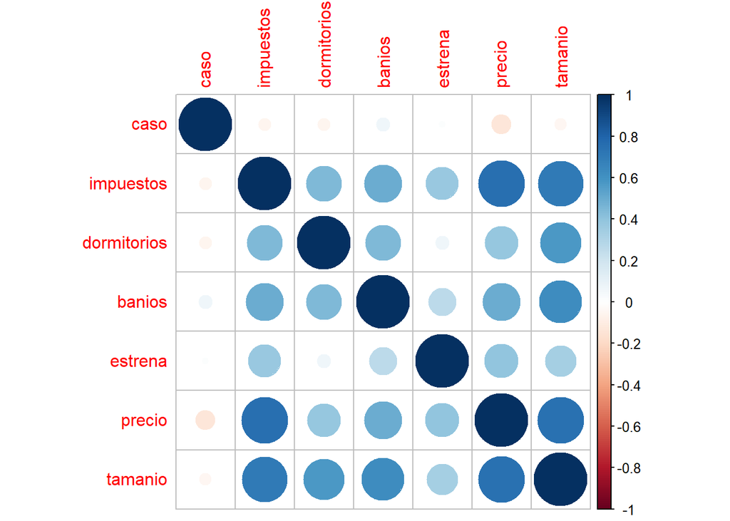

```r
library(corrplot)
corrplot(cor(preciocasas,method="s"))
```

normalidad de los residuos del modelo

```r
shapiro.test(modeleje1$residuals)
```

```
##
##  Shapiro-Wilk normality test
##
## data:  modeleje1$residuals
## W = 0.93424, p-value = 8.729e-05
```

Tampoco los residuos del modelo son normales.

- homocedastisidad

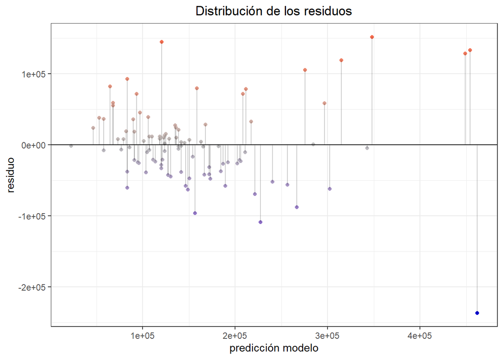

```r
preciocasas2<-preciocasas
preciocasas2$prediccion <- modeleje1$fitted.values
preciocasas2$residuos <- modeleje1$residuals

ggplot(data = preciocasas2, aes(x = prediccion, y = residuos)) +
  geom_point(aes(color = residuos)) +
  scale_color_gradient2(low = "blue3", mid = "grey", high = "red") +
  geom_hline(yintercept = 0) + geom_segment(aes(xend = prediccion, yend = 0), alpha = 0.2) +
  labs(title = "Distribución de los residuos", x = "predicción modelo", y = "residuo") +
  theme_bw() +
  theme(plot.title = element_text(hjust = 0.5), legend.position = "none")
```

Paraciera tener estructura, los residuos se entienden que no son homocedasticos.

```r
library(lmtest) #carga la librería lmtest
bptest(modeleje1)
```

```
##
##  studentized Breusch-Pagan test
##
## data:  modeleje1
## BP = 37.299, df = 1, p-value = 1.013e-09
```

Se corrobora rechazo de la hipotesis nula de homecedastidad, los residuos son heterosedasticos.

- Independencia

```r
dwtest(modeleje1)
```

```
##
##  Durbin-Watson test
##
## data:  modeleje1
## DW = 1.4215, p-value = 0.001719
## alternative hypothesis: true autocorrelation is greater than 0
```

Se rechaza Ho, la hipótesis alternativa indica que existe una autocorrelación positiva mayor que cero en los residuos del modelo. Esto significa que hay evidencia de autocorrelación en los residuos del modelo, lo que sugiere que las observaciones están correlacionadas entre sí en cierta medida.

Outliers, puntos influyentes, y de alto leverage

Análisis de residuos y residuos estudentizados

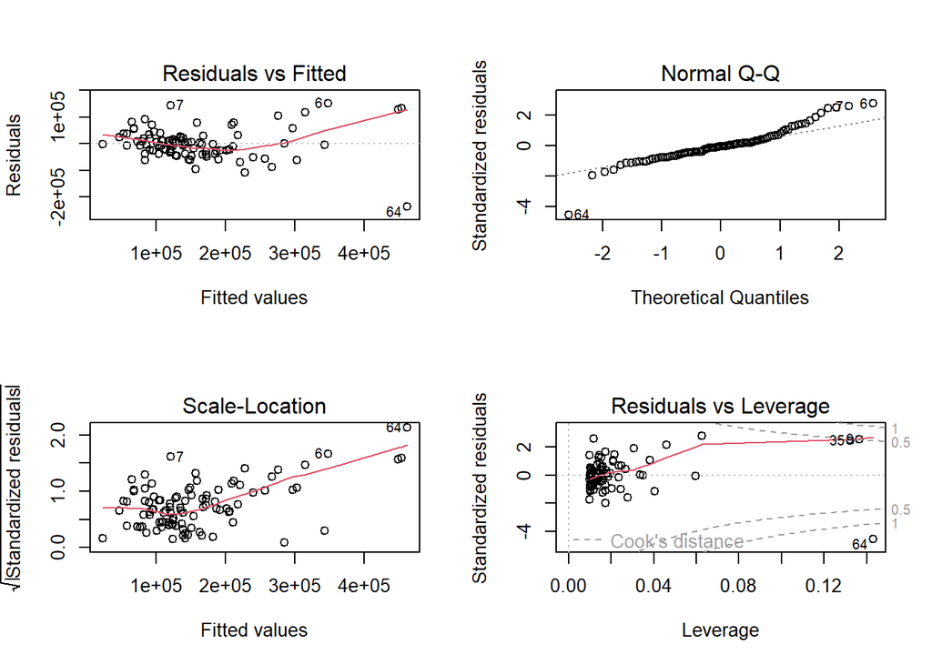

```r
par(mfrow=c(2,2))
plot(modeleje1)
```

```r
summary(influence.measures(model = modeleje1))
```

```
## Potentially influential observations of
##   lm(formula = precio ~ tamanio, data = preciocasas) :
##
##    dfb.1_  dfb.tamn dffit   cov.r   cook.d  hat
## 6  -0.52    0.69     0.75_*  0.92_*  0.26    0.06_*
## 7   0.20   -0.11     0.29    0.90_*  0.04    0.01
## 9  -0.82    1.00_*   1.04_*  1.03    0.51    0.14_*
## 22  0.02   -0.02    -0.02    1.09_*  0.00    0.06
## 35 -0.77    0.95     0.98_*  1.04    0.46    0.13_*
## 64  1.65_* -2.01_*  -2.08_*  0.74_*  1.73_*  0.14_*
## 76 -0.31    0.43     0.49_*  0.97    0.11    0.05
```

```r
which(dfbetas(modeleje1)[,2]>1)
```

```
## 9
## 9
```

```r
n<-length(preciocasas$precio)
p<-length(modeleje1$coefficients)
which(dffits(modeleje1)>2 * sqrt(p / n))
```

```
##  6  7  9 35 66 76
##  6  7  9 35 66 76
```

Otros puntos influyentes

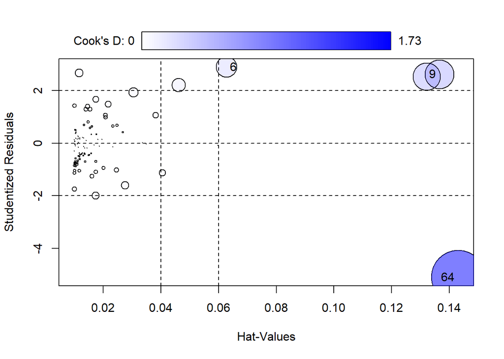

|  | StudRes | Hat | CookD |
| --- | --- | --- | --- |
| 6 | 2.890934 | 0.06272291 | 0.2601149 |
| 9 | 2.618641 | 0.13655462 | 0.5116615 |
| 64 | -5.099962 | 0.14306939 | 1.7297845 |

```r
library(car)
influencePlot(model = modeleje1)
```

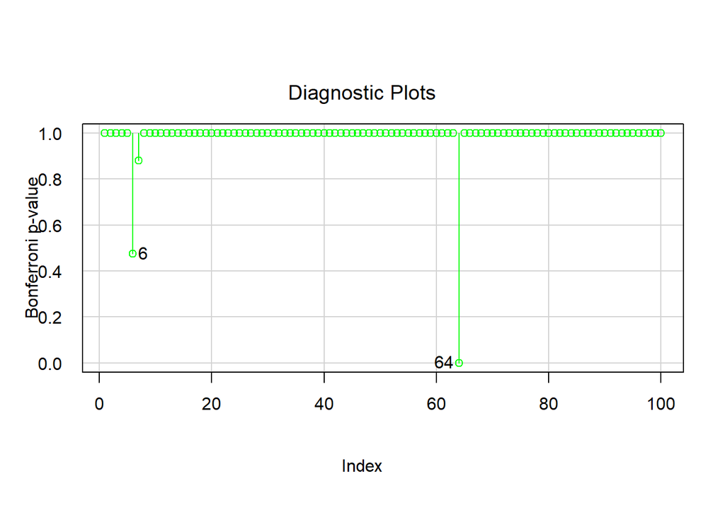

```r
influenceIndexPlot(modeleje1, vars='Bonf', las=1,col='green')
```

```r
outlierTest(modeleje1)
```

```
##     rstudent unadjusted p-value Bonferroni p
## 64 -5.099962         1.6833e-06   0.00016833
```

Se confirma la observación No. 64 es un punto influyent y outlier. La Observación 6 y 9 son de que resaltan entre los demas puntos influyentes.

El modelo no es adecuado porque no cumple los supuestos, aunque el R cuadro explica un 69,21 % de la variable respuesta no cumplen los supuestos de normalidad, varianza constante e independencia. Se debe validar una transformación.

## 3. Realizar una transformación de la variable respuesta para lograr normalidad en la distribución de los residuos. Indicar si el modelo con esta transformación resulta adecuado.

```r
library(MASS)
box_cox_result <- boxcox(precio ~ tamanio, lambda = -2:2, data = preciocasas)
```

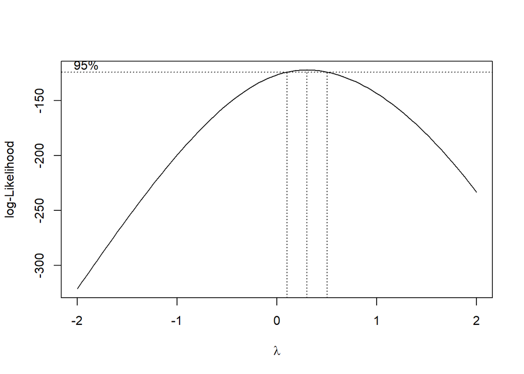

```r
# Se encuentra el valor óptimo de lambda que maximiza el logaritmo de verosimilitud
best_box_cox <- box_cox_result$x[which.max(box_cox_result$y)]

# Se ajusta un modelo de regresión lineal utilizando la variable dependiente "precio" elevada a la potencia óptima de lambda (best_box_cox) como la variable de respuesta y la variable independiente "tamanio".
model2eje1 <- lm((precio)^(best_box_cox) ~ tamanio, data = preciocasas)

summary(model2eje1)
```

```
##
## Call:
## lm(formula = (precio)^(best_box_cox) ~ tamanio, data = preciocasas)
##
## Residuals:
##     Min      1Q  Median      3Q     Max
## -12.710  -2.203   0.149   1.780   9.938
##
## Coefficients:
##              Estimate Std. Error t value Pr(>|t|)
## (Intercept) 2.378e+01  9.698e-01   24.52   <2e-16 ***
## tamanio     7.605e-03  5.513e-04   13.79   <2e-16 ***
## ---
## Signif. codes:  0 '***' 0.001 '**' 0.01 '*' 0.05 '.' 0.1 ' ' 1
##
## Residual standard error: 3.658 on 98 degrees of freedom
## Multiple R-squared:  0.6601, Adjusted R-squared:  0.6566
## F-statistic: 190.3 on 1 and 98 DF,  p-value: < 2.2e-16
```

En el modelo transformado se sigue observando que en general es significativo tanto de forma global como individual, el R cuadro baja un poco con relación al primer modelo pero aún sigue siendo representativo, 65.66%.

Se realiza analisis de los supuestos

**Normalidad**

```r
shapiro.test(model2eje1$residuals)
```

```
##
##  Shapiro-Wilk normality test
##
## data:  model2eje1$residuals
## W = 0.97017, p-value = 0.02279
```

Se rechaza normalidad, pero se observa que se acerca a la zona de no rechazo.

**Homocedastisidad**

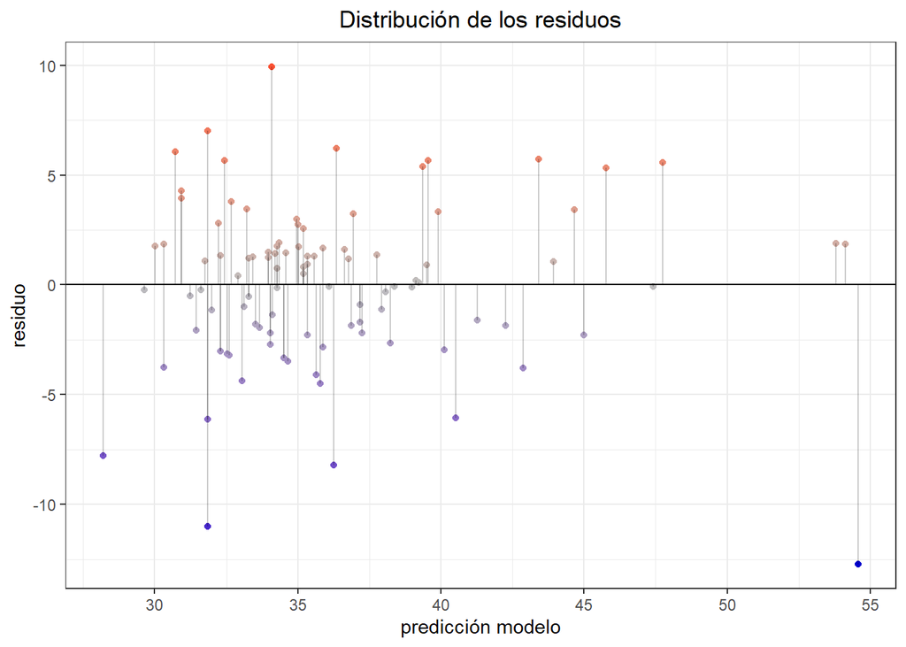

```r
preciocasas3<-preciocasas
preciocasas3$prediccion <- model2eje1$fitted.values
preciocasas3$residuos <- model2eje1$residuals

ggplot(data = preciocasas3, aes(x = prediccion, y = residuos)) +
  geom_point(aes(color = residuos)) +
  scale_color_gradient2(low = "blue3", mid = "grey", high = "red") +
  geom_hline(yintercept = 0) + geom_segment(aes(xend = prediccion, yend = 0), alpha = 0.2) +
  labs(title = "Distribución de los residuos", x = "predicción modelo", y = "residuo") +
  theme_bw() +
  theme(plot.title = element_text(hjust = 0.5), legend.position = "none")
```

```r
bptest(model2eje1)
```

```
##
##  studentized Breusch-Pagan test
##
## data:  model2eje1
## BP = 2.5644, df = 1, p-value = 0.1093
```

Los residuos son homocedasticos, con relación al modelo anterior se observa que se mejora para ser residuos homocedasticos.

**Independencia**

```r
dwtest(model2eje1)
```

```
##
##  Durbin-Watson test
##
## data:  model2eje1
## DW = 1.457, p-value = 0.003017
## alternative hypothesis: true autocorrelation is greater than 0
```

Se sigue rechazando Ho, existe autocorrelacion de los residuos del modelo.

Se intenta con un tercer modelo

```r
# Basado que el lamda optimo dio best_box_cox = 0.3030303, se intenta aproximandolo a cero
model3eje1 <- lm(log10(precio) ~ tamanio, data = preciocasas)
summary(model3eje1)
```

```
##
## Call:
## lm(formula = log10(precio) ~ tamanio, data = preciocasas)
##
## Residuals:
##      Min       1Q   Median       3Q      Max
## -0.60883 -0.07549  0.01939  0.08395  0.37968
##
## Coefficients:
##              Estimate Std. Error t value Pr(>|t|)
## (Intercept) 4.661e+00  4.130e-02  112.87   <2e-16 ***
## tamanio     2.826e-04  2.348e-05   12.04   <2e-16 ***
## ---
## Signif. codes:  0 '***' 0.001 '**' 0.01 '*' 0.05 '.' 0.1 ' ' 1
##
## Residual standard error: 0.1558 on 98 degrees of freedom
## Multiple R-squared:  0.5966, Adjusted R-squared:  0.5925
## F-statistic: 144.9 on 1 and 98 DF,  p-value: < 2.2e-16
```

**Normalidad**

```r
shapiro.test(model3eje1$residuals)
```

```
##
##  Shapiro-Wilk normality test
##
## data:  model3eje1$residuals
## W = 0.93553, p-value = 0.000104
```

Sigue sin cumplir normalidad

```r
model4eje1 <- lm((precio) ~ log10(tamanio), data = preciocasas)
summary(model4eje1)
```

```
##
## Call:
## lm(formula = (precio) ~ log10(tamanio), data = preciocasas)
##
## Residuals:
##     Min      1Q  Median      3Q     Max
## -142895  -39419  -11344   21418  222344
##
## Coefficients:
##                Estimate Std. Error t value Pr(>|t|)
## (Intercept)    -1434730     130468   -11.0   <2e-16 ***
## log10(tamanio)   499695      40951    12.2   <2e-16 ***
## ---
## Signif. codes:  0 '***' 0.001 '**' 0.01 '*' 0.05 '.' 0.1 ' ' 1
##
## Residual standard error: 64120 on 98 degrees of freedom
## Multiple R-squared:  0.6031, Adjusted R-squared:  0.599
## F-statistic: 148.9 on 1 and 98 DF,  p-value: < 2.2e-16
```

**Normalidad**

```r
shapiro.test(model4eje1$residuals)
```

```
##
##  Shapiro-Wilk normality test
##
## data:  model4eje1$residuals
## W = 0.92499, p-value = 2.614e-05
```

Sigue sin cumplir normalidad

```r
model5eje1 <- lm(log10(precio) ~ log10(tamanio), data = preciocasas)
summary(model5eje1)
```

```
##
## Call:
## lm(formula = log10(precio) ~ log10(tamanio), data = preciocasas)
##
## Residuals:
##      Min       1Q   Median       3Q      Max
## -0.57761 -0.09381  0.02051  0.08645  0.36359
##
## Coefficients:
##                Estimate Std. Error t value Pr(>|t|)
## (Intercept)     1.22232    0.30581   3.997 0.000124 ***
## log10(tamanio)  1.22549    0.09599  12.767  < 2e-16 ***
## ---
## Signif. codes:  0 '***' 0.001 '**' 0.01 '*' 0.05 '.' 0.1 ' ' 1
##
## Residual standard error: 0.1503 on 98 degrees of freedom
## Multiple R-squared:  0.6245, Adjusted R-squared:  0.6207
## F-statistic:   163 on 1 and 98 DF,  p-value: < 2.2e-16
```

**Normalidad**

```r
shapiro.test(model5eje1$residuals)
```

```
##
##  Shapiro-Wilk normality test
##
## data:  model5eje1$residuals
## W = 0.97528, p-value = 0.0568
```

Se cumple el supuesto de normalidad, esto muy cerca de la zona de rechazo.

**Homocedasticidad**

```r
bptest(model5eje1)
```

```
##
##  studentized Breusch-Pagan test
##
## data:  model5eje1
## BP = 2.2799, df = 1, p-value = 0.1311
```

Se cumple el supuesto de homocedastisidad de los residuos.

**Independencia**

```r
dwtest(model5eje1)
```

```
##
##  Durbin-Watson test
##
## data:  model5eje1
## DW = 1.5899, p-value = 0.01891
## alternative hypothesis: true autocorrelation is greater than 0
```

No se cumple independencia.

El modelo 5 no cumple los supuestos.

Función de cumplimientos de supuestos

```r
#Funcion de cumplimientos de supuestos
Respuesta <- matrix(0, nrow = 8, ncol = 1)

cumplimientoSupuestos <- function(modeloLineal) {
  #Supuesto de normalidad
  Normalidad=shapiro.test(modeloLineal$residuals)
    if (Normalidad$p.value>0.05){
      Respuesta[1,1]="Los residuos del modelo son normales basado en el test de Shapiro"

      p_value <- Normalidad$p.value
      texto <- paste("En este caso, como el valor p (", p_value, ") es mayor que el nivel de significancia (0.05), no se tiene suficiente evidencia para rechazar la hipótesis nula de normalidad. Por lo tanto, se puede considerar que los residuos del modelo siguen una distribución normal.")
      Respuesta[2,1] <- texto


    } else {

      Respuesta[1,1]="Los residuos del modelo no son normales basado en el test de Shapiro"

      p_value <- Normalidad$p.value
      texto <- paste("En este caso, como el valor p (", p_value, ") es menor que el nivel de significancia (0.05), se tiene suficiente evidencia para rechazar la hipótesis nula de normalidad. Por lo tanto, se puede considerar que los residuos del modelo no siguen una distribución normal.")
      Respuesta[2,1] <- texto


    }

  Respuesta[3,1]="----------------------------------------------------------------------------------------------------"

  #Supuesto de homocedastisidad
  homocedastisidad=bptest(modeloLineal)
    if (homocedastisidad$p.value>0.05){
      Respuesta[4,1]="Los errores del modelo son homocedastico basado en el test de Breusch-Pagan"
      p_value <- homocedastisidad$p.value
      texto <- paste("En este caso, como el valor p (", p_value, ") es mayor que el nivel de significancia establecido (0.05), no se tiene suficiente evidencia para rechazar la hipótesis nula de homocedasticidad. Por lo tanto, se puede considerar que los errores del modelo tienen varianzas constantes (homocedasticidad).")
      Respuesta[5,1] <- texto


    }else {
      Respuesta[4,1]="Los errores del modelo no son homocedastico basado en el test de Breusch-Pagan"
      p_value <- homocedastisidad$p.value
      texto <- paste("En este caso, como el valor p (", p_value, ") es menor que el nivel de significancia establecido (0.05), se tiene suficiente evidencia para rechazar la hipótesis nula de homocedasticidad. Por lo tanto, se puede considerar que los errores del modelo no tienen varianzas constantes (heterosedasticos).")
      Respuesta[5,1] <- texto
    }

   Respuesta[6,1]="----------------------------------------------------------------------------------------------------"
  #Supuesto de independencia
  independencia=dwtest(modeloLineal)
    if (independencia$p.value>0.05){
      Respuesta[7,1]="Los errores del modelo son independientes basado en el test de Durbin-Watson"
      p_value <- independencia$p.value
      texto <- paste("En este caso, como el valor p (", p_value, ") es mayor que el nivel de significancia establecido (0.05), se tiene suficiente evidencia para no rechazar la hipótesis nula de independencia de los errores. Por lo tanto, se puede concluir que no existe autocorrelación en los errores del modelo.")
      Respuesta[8,1] <- texto
    }else {
      Respuesta[7,1]="Los errores del modelo no son independientes basado en el test de Durbin-Watson"
      p_value <- independencia$p.value
      texto <- paste("En este caso, como el valor p (", p_value, ") es menor que el nivel de significancia establecido (0.05), se tiene suficiente evidencia para rechazar la hipótesis nula de independencia de los errores. Por lo tanto, se puede concluir que existe autocorrelación en los errores del modelo.")
      Respuesta[8,1] <- texto
    }

  return(Respuesta)

}

#cumplimientoSupuestos(model5eje1)
```

Se resume a continuación los supuestos de los modelos trabajados:

```r
cumplimientoSupuestos(model5eje1)
```

```
##      [,1]
## [1,] "Los residuos del modelo son normales basado en el test de Shapiro"
## [2,] "En este caso, como el valor p ( 0.0567991488317333 ) es mayor que el nivel de significancia (0.05), no se tiene suficiente evidencia para rechazar la hipótesis nula de normalidad. Por lo tanto, se puede considerar que los residuos del modelo siguen una distribución normal."
## [3,] "----------------------------------------------------------------------------------------------------"
## [4,] "Los errores del modelo son homocedastico basado en el test de Breusch-Pagan"
## [5,] "En este caso, como el valor p ( 0.131056216975795 ) es mayor que el nivel de significancia establecido (0.05), no se tiene suficiente evidencia para rechazar la hipótesis nula de homocedasticidad. Por lo tanto, se puede considerar que los errores del modelo tienen varianzas constantes (homo…
## [6,] "----------------------------------------------------------------------------------------------------"
## [7,] "Los errores del modelo no son independientes basado en el test de Durbin-Watson"
## [8,] "En este caso, como el valor p ( 0.0189062565494348 ) es menor que el nivel de significancia establecido (0.05), se tiene suficiente evidencia para rechazar la hipótesis nula de independencia de los errores. Por lo tanto, se puede concluir que existe autocorrelación en los errores del modelo…
```

```r
cumplimientoSupuestos(model4eje1)
```

```
##      [,1]
## [1,] "Los residuos del modelo no son normales basado en el test de Shapiro"
## [2,] "En este caso, como el valor p ( 2.61372451211621e-05 ) es menor que el nivel de significancia (0.05), se tiene suficiente evidencia para rechazar la hipótesis nula de normalidad. Por lo tanto, se puede considerar que los residuos del modelo no siguen una distribución normal."
## [3,] "----------------------------------------------------------------------------------------------------"
## [4,] "Los errores del modelo no son homocedastico basado en el test de Breusch-Pagan"
## [5,] "En este caso, como el valor p ( 4.52649851759847e-07 ) es menor que el nivel de significancia establecido (0.05), se tiene suficiente evidencia para rechazar la hipótesis nula de homocedasticidad. Por lo tanto, se puede considerar que los errores del modelo no tienen varianzas constantes (h…
## [6,] "----------------------------------------------------------------------------------------------------"
## [7,] "Los errores del modelo no son independientes basado en el test de Durbin-Watson"
## [8,] "En este caso, como el valor p ( 0.0119892034291876 ) es menor que el nivel de significancia establecido (0.05), se tiene suficiente evidencia para rechazar la hipótesis nula de independencia de los errores. Por lo tanto, se puede concluir que existe autocorrelación en los errores del modelo…
```

```r
cumplimientoSupuestos(model3eje1)
```

```
##      [,1]
## [1,] "Los residuos del modelo no son normales basado en el test de Shapiro"
## [2,] "En este caso, como el valor p ( 0.000104017861220539 ) es menor que el nivel de significancia (0.05), se tiene suficiente evidencia para rechazar la hipótesis nula de normalidad. Por lo tanto, se puede considerar que los residuos del modelo no siguen una distribución normal."
## [3,] "----------------------------------------------------------------------------------------------------"
## [4,] "Los errores del modelo son homocedastico basado en el test de Breusch-Pagan"
## [5,] "En este caso, como el valor p ( 0.59149725806018 ) es mayor que el nivel de significancia establecido (0.05), no se tiene suficiente evidencia para rechazar la hipótesis nula de homocedasticidad. Por lo tanto, se puede considerar que los errores del modelo tienen varianzas constantes (homoc…
## [6,] "----------------------------------------------------------------------------------------------------"
## [7,] "Los errores del modelo no son independientes basado en el test de Durbin-Watson"
## [8,] "En este caso, como el valor p ( 0.0182886157479454 ) es menor que el nivel de significancia establecido (0.05), se tiene suficiente evidencia para rechazar la hipótesis nula de independencia de los errores. Por lo tanto, se puede concluir que existe autocorrelación en los errores del modelo…
```

```r
cumplimientoSupuestos(model2eje1)
```

```
##      [,1]
## [1,] "Los residuos del modelo no son normales basado en el test de Shapiro"
## [2,] "En este caso, como el valor p ( 0.0227861519075747 ) es menor que el nivel de significancia (0.05), se tiene suficiente evidencia para rechazar la hipótesis nula de normalidad. Por lo tanto, se puede considerar que los residuos del modelo no siguen una distribución normal."
## [3,] "----------------------------------------------------------------------------------------------------"
## [4,] "Los errores del modelo son homocedastico basado en el test de Breusch-Pagan"
## [5,] "En este caso, como el valor p ( 0.109293430708518 ) es mayor que el nivel de significancia establecido (0.05), no se tiene suficiente evidencia para rechazar la hipótesis nula de homocedasticidad. Por lo tanto, se puede considerar que los errores del modelo tienen varianzas constantes (homo…
## [6,] "----------------------------------------------------------------------------------------------------"
## [7,] "Los errores del modelo no son independientes basado en el test de Durbin-Watson"
## [8,] "En este caso, como el valor p ( 0.00301677360555826 ) es menor que el nivel de significancia establecido (0.05), se tiene suficiente evidencia para rechazar la hipótesis nula de independencia de los errores. Por lo tanto, se puede concluir que existe autocorrelación en los errores del model…
```

```r
cumplimientoSupuestos(modeleje1)
```

```
##      [,1]
## [1,] "Los residuos del modelo no son normales basado en el test de Shapiro"
## [2,] "En este caso, como el valor p ( 8.72897550761266e-05 ) es menor que el nivel de significancia (0.05), se tiene suficiente evidencia para rechazar la hipótesis nula de normalidad. Por lo tanto, se puede considerar que los residuos del modelo no siguen una distribución normal."
## [3,] "----------------------------------------------------------------------------------------------------"
## [4,] "Los errores del modelo no son homocedastico basado en el test de Breusch-Pagan"
## [5,] "En este caso, como el valor p ( 1.013482031137e-09 ) es menor que el nivel de significancia establecido (0.05), se tiene suficiente evidencia para rechazar la hipótesis nula de homocedasticidad. Por lo tanto, se puede considerar que los errores del modelo no tienen varianzas constantes (het…
## [6,] "----------------------------------------------------------------------------------------------------"
## [7,] "Los errores del modelo no son independientes basado en el test de Durbin-Watson"
## [8,] "En este caso, como el valor p ( 0.00171926211302137 ) es menor que el nivel de significancia establecido (0.05), se tiene suficiente evidencia para rechazar la hipótesis nula de independencia de los errores. Por lo tanto, se puede concluir que existe autocorrelación en los errores del model…
```

función resumen de cumplimientos de los modelos

```r
resumenCumplimiento <- function(cantidadModelos, ...) {
  modelos <- list(...)
  resultado <- matrix(0, nrow = cantidadModelos + 1, ncol = 5)

  # Nombre de la columna
  resultado[1, 1] <- "Modelos"

  # Obtener los nombres de los modelos como texto
  modelos_texto <- as.character(substitute(list(...)))[-1]

  for (i in 1:cantidadModelos) {
    # Asignar el nombre del modelo a la matriz resultado
    resultado[i + 1, 1] <- modelos_texto[i]

    # Nombre de la columna
    resultado[1, 2] <- "Normalidad"

    # Se obtiene el resultado de la función cumplimientoSupuestos
    resultado[i + 1, 2] <- cumplimientoSupuestos(modelos[[i]])[1, 1]

    #Reducción del texto
    if(resultado[i + 1, 2]=="Los residuos del modelo son normales basado en el test de Shapiro"){
      resultado[i + 1, 2] <- "Hay normalidad"
    }else{
      resultado[i + 1, 2] <- "No hay normalidad"
    }

    # Nombre de la columna 3
    resultado[1, 3] <- "Homocedasticidad"

    # Se obtiene el resultado de la función cumplimientoSupuestos
    resultado[i + 1, 3] <- cumplimientoSupuestos(modelos[[i]])[4, 1]
    resultado[i + 1, 3]
    #Reducción del texto
    if(resultado[i + 1, 3]=="Los errores del modelo son homocedastico basado en el test de Breusch-Pagan"){
      resultado[i + 1, 3] <- "Hay homocedasticidad"
    }else{
      resultado[i + 1, 3] <- "No hay homocedasticidad"
    }


    # Nombre de la columna 4
    resultado[1, 4] <- "Independencia"

    # Se obtiene el resultado de la función cumplimientoSupuestos
    resultado[i + 1, 4] <- cumplimientoSupuestos(modelos[[i]])[7, 1]
    resultado[i + 1, 4]
    #Reducción del texto
    if(resultado[i + 1, 4]=="Los errores del modelo son independientes basado en el test de Durbin-Watson"){
      resultado[i + 1, 4] <- "Hay independencia"
    }else{
      resultado[i + 1, 4] <- "No hay independencia"
    }

    # Nombre de la columna
    resultado[1, 5] <- "Cumplimiento"

    if (resultado[i + 1, 2] == "Hay normalidad" & resultado[i + 1, 3]=="Hay homocedasticidad" & resultado[i + 1, 4]=="Hay independencia") {
      resultado[i + 1, 5] <- "Si"
    } else {
      resultado[i + 1, 5] <- "No"
    }
  }

  return(resultado)

}
```

```r
resumenCumplimiento(5,modeleje1,model2eje1,model3eje1,model4eje1,model5eje1)
```

```
##      [,1]         [,2]                [,3]
## [1,] "Modelos"    "Normalidad"        "Homocedasticidad"
## [2,] "modeleje1"  "No hay normalidad" "No hay homocedasticidad"
## [3,] "model2eje1" "No hay normalidad" "Hay homocedasticidad"
## [4,] "model3eje1" "No hay normalidad" "Hay homocedasticidad"
## [5,] "model4eje1" "No hay normalidad" "No hay homocedasticidad"
## [6,] "model5eje1" "Hay normalidad"    "Hay homocedasticidad"
##      [,4]                   [,5]
## [1,] "Independencia"        "Cumplimiento"
## [2,] "No hay independencia" "No"
## [3,] "No hay independencia" "No"
## [4,] "No hay independencia" "No"
## [5,] "No hay independencia" "No"
## [6,] "No hay independencia" "No"
```

Ninguno de los modelos cumplen los supuestos.

```r
box_cox_result2 <- boxcox(precio ~ log10(tamanio), lambda = -2:2, data = preciocasas)
```

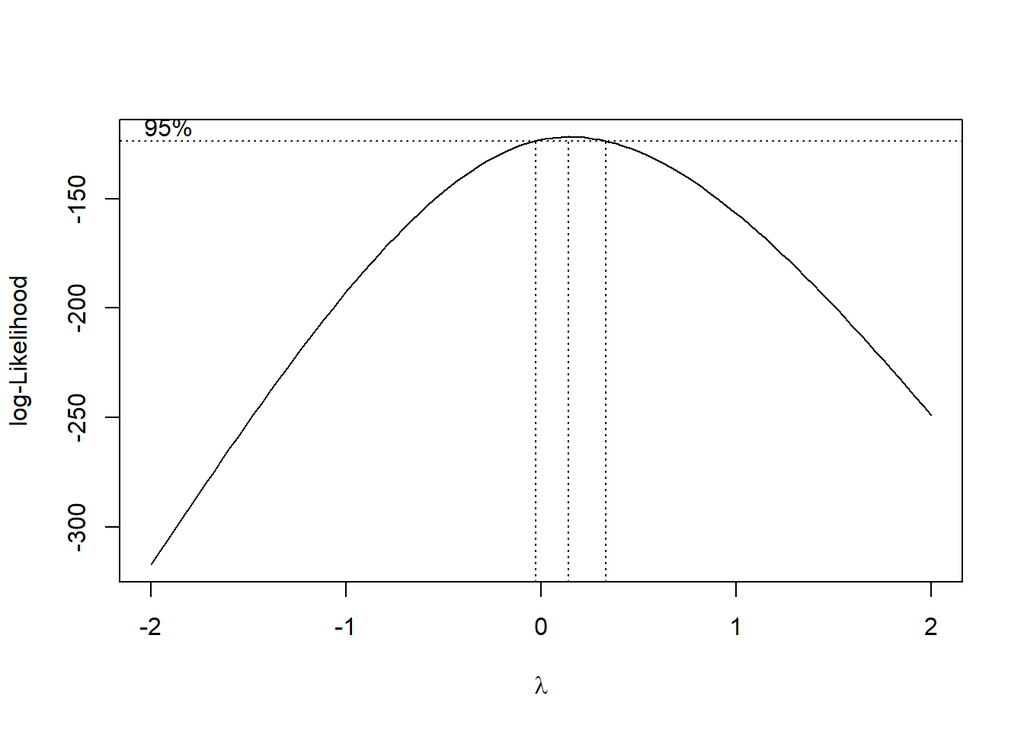

```r
# Se encuentra el valor óptimo de lambda que maximiza el logaritmo de verosimilitud
best_box_cox2 <- box_cox_result2$x[which.max(box_cox_result$y)]

# Se ajusta un modelo de regresión lineal utilizando la variable dependiente "precio" elevada a la potencia óptima de lambda (best_box_cox) como la variable de respuesta y la variable independiente "tamanio".
model2Box2eje1 <- lm((precio)^(best_box_cox2) ~ tamanio, data = preciocasas)

summary(model2Box2eje1)
```

```
##
## Call:
## lm(formula = (precio)^(best_box_cox2) ~ tamanio, data = preciocasas)
##
## Residuals:
##     Min      1Q  Median      3Q     Max
## -12.710  -2.203   0.149   1.780   9.938
##
## Coefficients:
##              Estimate Std. Error t value Pr(>|t|)
## (Intercept) 2.378e+01  9.698e-01   24.52   <2e-16 ***
## tamanio     7.605e-03  5.513e-04   13.79   <2e-16 ***
## ---
## Signif. codes:  0 '***' 0.001 '**' 0.01 '*' 0.05 '.' 0.1 ' ' 1
##
## Residual standard error: 3.658 on 98 degrees of freedom
## Multiple R-squared:  0.6601, Adjusted R-squared:  0.6566
## F-statistic: 190.3 on 1 and 98 DF,  p-value: < 2.2e-16
```

```r
cumplimientoSupuestos(model2Box2eje1)
```

```
##      [,1]
## [1,] "Los residuos del modelo no son normales basado en el test de Shapiro"
## [2,] "En este caso, como el valor p ( 0.0227861519075747 ) es menor que el nivel de significancia (0.05), se tiene suficiente evidencia para rechazar la hipótesis nula de normalidad. Por lo tanto, se puede considerar que los residuos del modelo no siguen una distribución normal."
## [3,] "----------------------------------------------------------------------------------------------------"
## [4,] "Los errores del modelo son homocedastico basado en el test de Breusch-Pagan"
## [5,] "En este caso, como el valor p ( 0.109293430708518 ) es mayor que el nivel de significancia establecido (0.05), no se tiene suficiente evidencia para rechazar la hipótesis nula de homocedasticidad. Por lo tanto, se puede considerar que los errores del modelo tienen varianzas constantes (homo…
## [6,] "----------------------------------------------------------------------------------------------------"
## [7,] "Los errores del modelo no son independientes basado en el test de Durbin-Watson"
## [8,] "En este caso, como el valor p ( 0.00301677360555826 ) es menor que el nivel de significancia establecido (0.05), se tiene suficiente evidencia para rechazar la hipótesis nula de independencia de los errores. Por lo tanto, se puede concluir que existe autocorrelación en los errores del model…
```

```r
model2Box22eje1 <- lm(log10(precio) ~ tamanio, data = preciocasas)

summary(model2Box22eje1)
```

```
##
## Call:
## lm(formula = log10(precio) ~ tamanio, data = preciocasas)
##
## Residuals:
##      Min       1Q   Median       3Q      Max
## -0.60883 -0.07549  0.01939  0.08395  0.37968
##
## Coefficients:
##              Estimate Std. Error t value Pr(>|t|)
## (Intercept) 4.661e+00  4.130e-02  112.87   <2e-16 ***
## tamanio     2.826e-04  2.348e-05   12.04   <2e-16 ***
## ---
## Signif. codes:  0 '***' 0.001 '**' 0.01 '*' 0.05 '.' 0.1 ' ' 1
##
## Residual standard error: 0.1558 on 98 degrees of freedom
## Multiple R-squared:  0.5966, Adjusted R-squared:  0.5925
## F-statistic: 144.9 on 1 and 98 DF,  p-value: < 2.2e-16
```

```r
cumplimientoSupuestos(model2Box22eje1)
```

```
##      [,1]
## [1,] "Los residuos del modelo no son normales basado en el test de Shapiro"
## [2,] "En este caso, como el valor p ( 0.000104017861220539 ) es menor que el nivel de significancia (0.05), se tiene suficiente evidencia para rechazar la hipótesis nula de normalidad. Por lo tanto, se puede considerar que los residuos del modelo no siguen una distribución normal."
## [3,] "----------------------------------------------------------------------------------------------------"
## [4,] "Los errores del modelo son homocedastico basado en el test de Breusch-Pagan"
## [5,] "En este caso, como el valor p ( 0.59149725806018 ) es mayor que el nivel de significancia establecido (0.05), no se tiene suficiente evidencia para rechazar la hipótesis nula de homocedasticidad. Por lo tanto, se puede considerar que los errores del modelo tienen varianzas constantes (homoc…
## [6,] "----------------------------------------------------------------------------------------------------"
## [7,] "Los errores del modelo no son independientes basado en el test de Durbin-Watson"
## [8,] "En este caso, como el valor p ( 0.0182886157479454 ) es menor que el nivel de significancia establecido (0.05), se tiene suficiente evidencia para rechazar la hipótesis nula de independencia de los errores. Por lo tanto, se puede concluir que existe autocorrelación en los errores del modelo…
```

```r
box_cox_result3 <- boxcox(log10(precio) ~ log10(tamanio), lambda = -2:10, data = preciocasas)
```

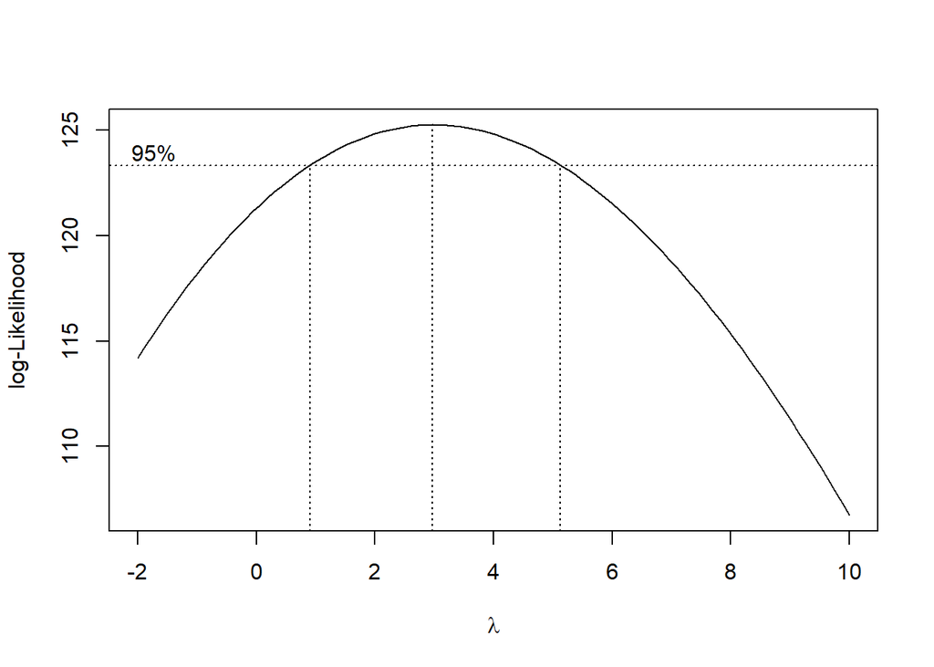

```r
# Se encuentra el valor óptimo de lambda que maximiza el logaritmo de verosimilitud
best_box_cox3 <- box_cox_result3$x[which.max(box_cox_result$y)]

# Se ajusta un modelo de regresión lineal utilizando la variable dependiente "precio" elevada a la potencia óptima de lambda (best_box_cox) como la variable de respuesta y la variable independiente "tamanio".
model2Box3eje1 <- lm((precio)^(best_box_cox3) ~ tamanio, data = preciocasas)

summary(model2Box3eje1)
```

```
##
## Call:
## lm(formula = (precio)^(best_box_cox3) ~ tamanio, data = preciocasas)
##
## Residuals:
##        Min         1Q     Median         3Q        Max
## -7.206e+27 -9.163e+26 -3.522e+25  6.675e+26  1.361e+28
##
## Coefficients:
##               Estimate Std. Error t value Pr(>|t|)
## (Intercept) -3.893e+27  6.251e+26  -6.227 1.18e-08 ***
## tamanio      2.787e+24  3.553e+23   7.843 5.47e-12 ***
## ---
## Signif. codes:  0 '***' 0.001 '**' 0.01 '*' 0.05 '.' 0.1 ' ' 1
##
## Residual standard error: 2.358e+27 on 98 degrees of freedom
## Multiple R-squared:  0.3856, Adjusted R-squared:  0.3794
## F-statistic: 61.52 on 1 and 98 DF,  p-value: 5.471e-12
```

```r
cumplimientoSupuestos(model2Box3eje1)
```

```
##      [,1]
## [1,] "Los residuos del modelo no son normales basado en el test de Shapiro"
## [2,] "En este caso, como el valor p ( 2.33314948678254e-13 ) es menor que el nivel de significancia (0.05), se tiene suficiente evidencia para rechazar la hipótesis nula de normalidad. Por lo tanto, se puede considerar que los residuos del modelo no siguen una distribución normal."
## [3,] "----------------------------------------------------------------------------------------------------"
## [4,] "Los errores del modelo no son homocedastico basado en el test de Breusch-Pagan"
## [5,] "En este caso, como el valor p ( 3.80679629706979e-10 ) es menor que el nivel de significancia establecido (0.05), se tiene suficiente evidencia para rechazar la hipótesis nula de homocedasticidad. Por lo tanto, se puede considerar que los errores del modelo no tienen varianzas constantes (h…
## [6,] "----------------------------------------------------------------------------------------------------"
## [7,] "Los errores del modelo son independientes basado en el test de Durbin-Watson"
## [8,] "En este caso, como el valor p ( 0.352251020313067 ) es mayor que el nivel de significancia establecido (0.05), se tiene suficiente evidencia para no rechazar la hipótesis nula de independencia de los errores. Por lo tanto, se puede concluir que no existe autocorrelación en los errores del m…
```

De la revision se puede considerar que se debe utilizar un modelo robusto, esto debido a que no se logra normalizar los datos con las transformación box y cox. a continuación se presenta un resumen de los modelos utilizados:

```r
resumenCumplimiento(8,modeleje1,model2eje1,model3eje1,model4eje1,model5eje1,model2Box3eje1,model2Box2eje1,model2Box22eje1)
```

```
##       [,1]              [,2]                [,3]
##  [1,] "Modelos"         "Normalidad"        "Homocedasticidad"
##  [2,] "modeleje1"       "No hay normalidad" "No hay homocedasticidad"
##  [3,] "model2eje1"      "No hay normalidad" "Hay homocedasticidad"
##  [4,] "model3eje1"      "No hay normalidad" "Hay homocedasticidad"
##  [5,] "model4eje1"      "No hay normalidad" "No hay homocedasticidad"
##  [6,] "model5eje1"      "Hay normalidad"    "Hay homocedasticidad"
##  [7,] "model2Box3eje1"  "No hay normalidad" "No hay homocedasticidad"
##  [8,] "model2Box2eje1"  "No hay normalidad" "Hay homocedasticidad"
##  [9,] "model2Box22eje1" "No hay normalidad" "Hay homocedasticidad"
##       [,4]                   [,5]
##  [1,] "Independencia"        "Cumplimiento"
##  [2,] "No hay independencia" "No"
##  [3,] "No hay independencia" "No"
##  [4,] "No hay independencia" "No"
##  [5,] "No hay independencia" "No"
##  [6,] "No hay independencia" "No"
##  [7,] "Hay independencia"    "No"
##  [8,] "No hay independencia" "No"
##  [9,] "No hay independencia" "No"
```

función para encontrar la mejor transformación box y cox (pendiente validar)

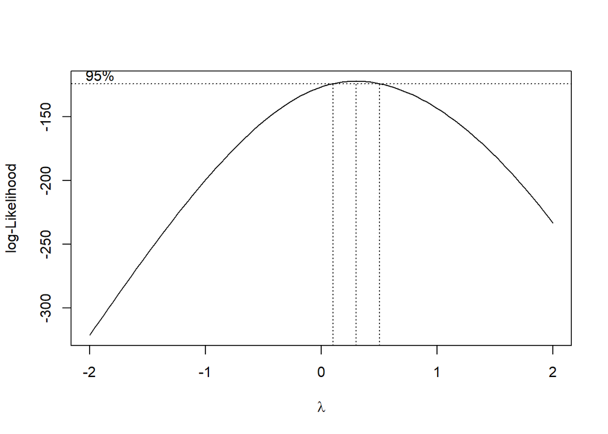

```
##      [,1]
## [1,] "Los residuos del modelo no son normales basado en el test de Shapiro"
## [2,] "En este caso, como el valor p ( 0.0227861519075747 ) es menor que el nivel de significancia (0.05), se tiene suficiente evidencia para rechazar la hipótesis nula de normalidad. Por lo tanto, se puede considerar que los residuos del modelo no siguen una distribución normal."
## [3,] "----------------------------------------------------------------------------------------------------"
## [4,] "Los errores del modelo son homocedastico basado en el test de Breusch-Pagan"
## [5,] "En este caso, como el valor p ( 0.109293430708518 ) es mayor que el nivel de significancia establecido (0.05), no se tiene suficiente evidencia para rechazar la hipótesis nula de homocedasticidad. Por lo tanto, se puede considerar que los errores del modelo tienen varianzas constantes (homo…
## [6,] "----------------------------------------------------------------------------------------------------"
## [7,] "Los errores del modelo no son independientes basado en el test de Durbin-Watson"
## [8,] "En este caso, como el valor p ( 0.00301677360555826 ) es menor que el nivel de significancia establecido (0.05), se tiene suficiente evidencia para rechazar la hipótesis nula de independencia de los errores. Por lo tanto, se puede concluir que existe autocorrelación en los errores del model…
```

```r
mejorBoxYCox<- function(independiente, dependiente,datos){
  box_cox_result <- boxcox(independiente ~ dependiente, lambda = -2:2, data = datos)

  # Se encuentra el valor óptimo de lambda que maximiza el logaritmo de verosimilitud
  best_box_cox <- box_cox_result$x[which.max(box_cox_result$y)]

  # Se ajusta un modelo de regresión lineal utilizando la variable dependiente elevada a la potencia óptima de lambda (best_box_cox) como la variable de respuesta y la variable independiente si es distinta de cero, si es cero se realiza el logaritmo en base de 10 de la variable independiente.
  if (best_box_cox==0){
    model <- lm(log10(independiente) ~ dependiente, data = datos)

  } else {
    model <- lm((independiente)^(best_box_cox) ~ dependiente, data = datos)
  }



  return(cumplimientoSupuestos(model))
}

mejorBoxYCox(preciocasas$precio,preciocasas$tamanio,preciocasas)
```

## 4. Eliminar la observación 64 y ajustar nuevamente el segundo modelo evaluando su validez.

```r
# Eliminar la observación con id igual a 64
preciocasas_sin_obs64 <- subset(preciocasas, caso != 64)
preciocasas_sin_obs64
```

| caso | impuestos | dormitorios | banios | estrena | precio | tamanio |
| --- | --- | --- | --- | --- | --- | --- |
| 1 | 3104 | 4 | 2 | 0 | 279900 | 2048 |
| 2 | 1173 | 2 | 1 | 0 | 146500 | 912 |
| 3 | 3076 | 4 | 2 | 0 | 237700 | 1654 |
| 4 | 1608 | 3 | 2 | 0 | 200000 | 2068 |
| 5 | 1454 | 3 | 3 | 0 | 159900 | 1477 |
| 6 | 2997 | 3 | 2 | 1 | 499900 | 3153 |
| 7 | 4054 | 3 | 2 | 0 | 265500 | 1355 |
| 8 | 3002 | 3 | 2 | 1 | 289900 | 2075 |
| 9 | 6627 | 5 | 4 | 0 | 587000 | 3990 |
| 10 | 680 | 2 | 1 | 0 | 142500 | 1170 |

[output cut: 89 more lines]

```r
modeleje1p4= lm(precio ~ tamanio, data = preciocasas_sin_obs64 )
summary(modeleje1p4)
```

```
##
## Call:
## lm(formula = precio ~ tamanio, data = preciocasas_sin_obs64)
##
## Residuals:
##     Min      1Q  Median      3Q     Max
## -120713  -32188   -2600   23405  146294
##
## Coefficients:
##               Estimate Std. Error t value Pr(>|t|)
## (Intercept) -72910.478  13977.407  -5.216 1.03e-06 ***
## tamanio        141.783      8.124  17.453  < 2e-16 ***
## ---
## Signif. codes:  0 '***' 0.001 '**' 0.01 '*' 0.05 '.' 0.1 ' ' 1
##
## Residual standard error: 50150 on 97 degrees of freedom
## Multiple R-squared:  0.7585, Adjusted R-squared:  0.756
## F-statistic: 304.6 on 1 and 97 DF,  p-value: < 2.2e-16
```

```r
cumplimientoSupuestos(modeleje1p4)
```

```
##      [,1]
## [1,] "Los residuos del modelo son normales basado en el test de Shapiro"
## [2,] "En este caso, como el valor p ( 0.18813429001424 ) es mayor que el nivel de significancia (0.05), no se tiene suficiente evidencia para rechazar la hipótesis nula de normalidad. Por lo tanto, se puede considerar que los residuos del modelo siguen una distribución normal."
## [3,] "----------------------------------------------------------------------------------------------------"
## [4,] "Los errores del modelo no son homocedastico basado en el test de Breusch-Pagan"
## [5,] "En este caso, como el valor p ( 3.18127165443078e-05 ) es menor que el nivel de significancia establecido (0.05), se tiene suficiente evidencia para rechazar la hipótesis nula de homocedasticidad. Por lo tanto, se puede considerar que los errores del modelo no tienen varianzas constantes (h…
## [6,] "----------------------------------------------------------------------------------------------------"
## [7,] "Los errores del modelo no son independientes basado en el test de Durbin-Watson"
## [8,] "En este caso, como el valor p ( 0.00311365270738473 ) es menor que el nivel de significancia establecido (0.05), se tiene suficiente evidencia para rechazar la hipótesis nula de independencia de los errores. Por lo tanto, se puede concluir que existe autocorrelación en los errores del model…
```

Se observa que al retirar la observacion 64 el modelo lineal sensillo se sigue sin cumplir los supuesto, por otro lado, el r cuadro mejora a un 75.6%.

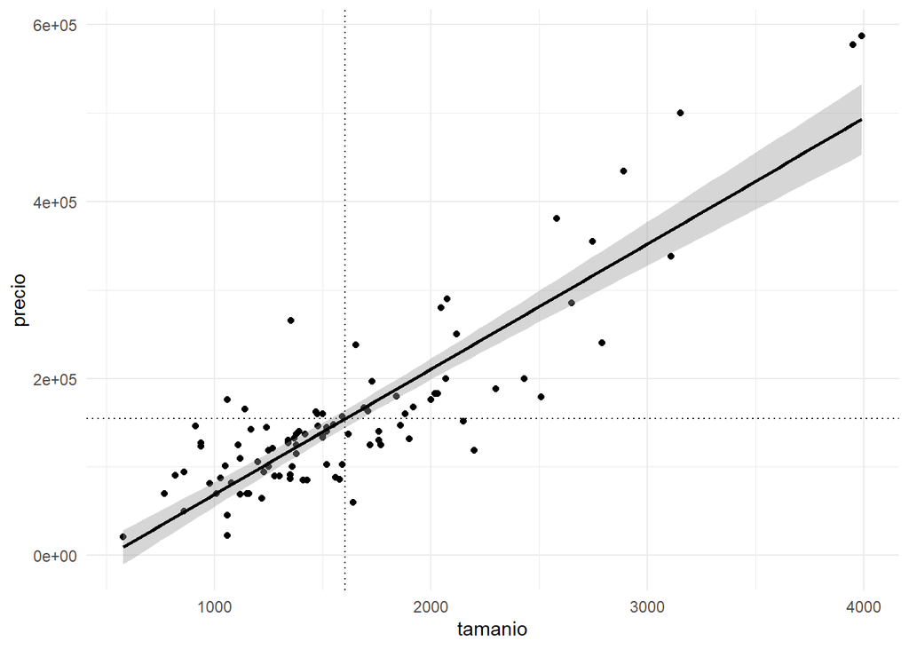

```r
promedioseje1p4 <- colMeans(preciocasas_sin_obs64)
ggplot(preciocasas_sin_obs64, aes(tamanio, precio)) +
  geom_point() +
  geom_vline(xintercept=promedioseje1p4[7],linetype="dotted") +
  geom_hline(yintercept=promedioseje1p4[6],linetype="dotted") +
  geom_smooth(method = "lm", se = TRUE, color = "black") +
  theme_minimal()
```

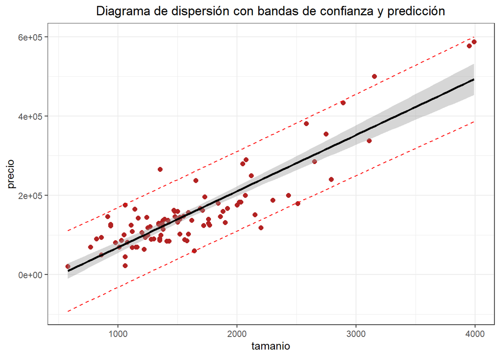

```r
ICcompleto<-predict(modeleje1p4, interval="confidence",level=0.95)
IPcompleto<-predict(modeleje1p4,newdata=data.frame(tamanio=preciocasas_sin_obs64$tamanio), interval="prediction",level=0.95)
datos<-data.frame(tamanio=preciocasas_sin_obs64$tamanio,precio=preciocasas_sin_obs64$precio,IPcompleto)

ggplot(data = datos, mapping = aes(x = tamanio, y = precio)) +
  geom_point(color = "firebrick", size = 2) +
  labs(title = "Diagrama de dispersión con bandas de confianza y predicción", x = "tamanio") +
  geom_line(aes(y=lwr), color="red" , linetype="dashed" ) +
  geom_line(aes(y=upr), color="red" , linetype="dashed" ) +
  geom_smooth(method = "lm", se = TRUE, color = "black") +
  theme_bw() + theme(plot.title = element_text(hjust = 0.5))
```

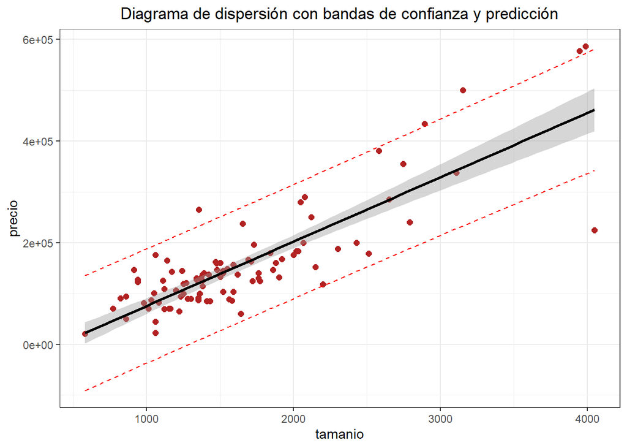

```r
#Grafica del primer modelo con el conjunto de datos total
ICcompleto<-predict(modeleje1, interval="confidence",level=0.95)
IPcompleto<-predict(modeleje1,newdata=data.frame(tamanio=preciocasas$tamanio), interval="prediction",level=0.95)
datos<-data.frame(tamanio=preciocasas$tamanio,precio=preciocasas$precio,IPcompleto)

ggplot(data = datos, mapping = aes(x = tamanio, y = precio)) +
  geom_point(color = "firebrick", size = 2) +
  labs(title = "Diagrama de dispersión con bandas de confianza y predicción", x = "tamanio") +
  geom_line(aes(y=lwr), color="red" , linetype="dashed" ) +
  geom_line(aes(y=upr), color="red" , linetype="dashed" ) +
  geom_smooth(method = "lm", se = TRUE, color = "black") +
  theme_bw() + theme(plot.title = element_text(hjust = 0.5))
```

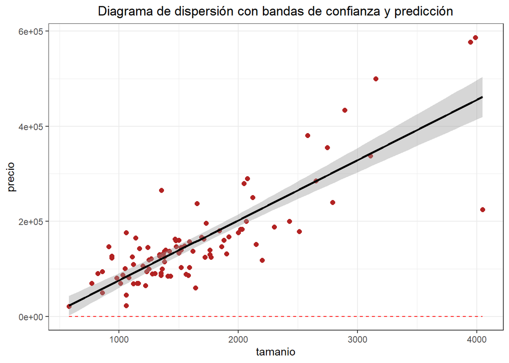

```r
#GRafica del mejor modelo con transformacion
ICcompleto<-predict(model5eje1, interval="confidence",level=0.95)
IPcompleto<-predict(model5eje1,newdata=data.frame(tamanio=preciocasas$tamanio), interval="prediction",level=0.95)
datos<-data.frame(tamanio=preciocasas$tamanio,precio=preciocasas$precio,IPcompleto)

ggplot(data = datos, mapping = aes(x = tamanio, y = precio)) +
  geom_point(color = "firebrick", size = 2) +
  labs(title = "Diagrama de dispersión con bandas de confianza y predicción", x = "tamanio") +
  geom_line(aes(y=lwr), color="red" , linetype="dashed" ) +
  geom_line(aes(y=upr), color="red" , linetype="dashed" ) +
  geom_smooth(method = "lm", se = TRUE, color = "black") +
  theme_bw() + theme(plot.title = element_text(hjust = 0.5))
```

función grafica con intervalos

```r
graficaMLIntervalos <- function(modelolineal,independiente,dependiente,dataset){
  ICcompleto<-predict(modelolineal, interval="confidence",level=0.95)
  IPcompleto<-predict(modelolineal,newdata=data.frame(independiente), interval="prediction",level=0.95)
  datos<-data.frame(independiente,dependiente,IPcompleto)

 grafica <- ggplot(data = datos, mapping = aes(x = independiente, y = precio)) +
    geom_point(color = "firebrick", size = 2) +
    labs(title = "Diagrama de dispersión con bandas de confianza y predicción", x = "tamanio") +
    geom_line(aes(y=lwr), color="red" , linetype="dashed" ) +
    geom_line(aes(y=upr), color="red" , linetype="dashed" ) +
    geom_smooth(method = "lm", se = TRUE, color = "black") +
    theme_bw() + theme(plot.title = element_text(hjust = 0.5))

 return(grafica)
}
```

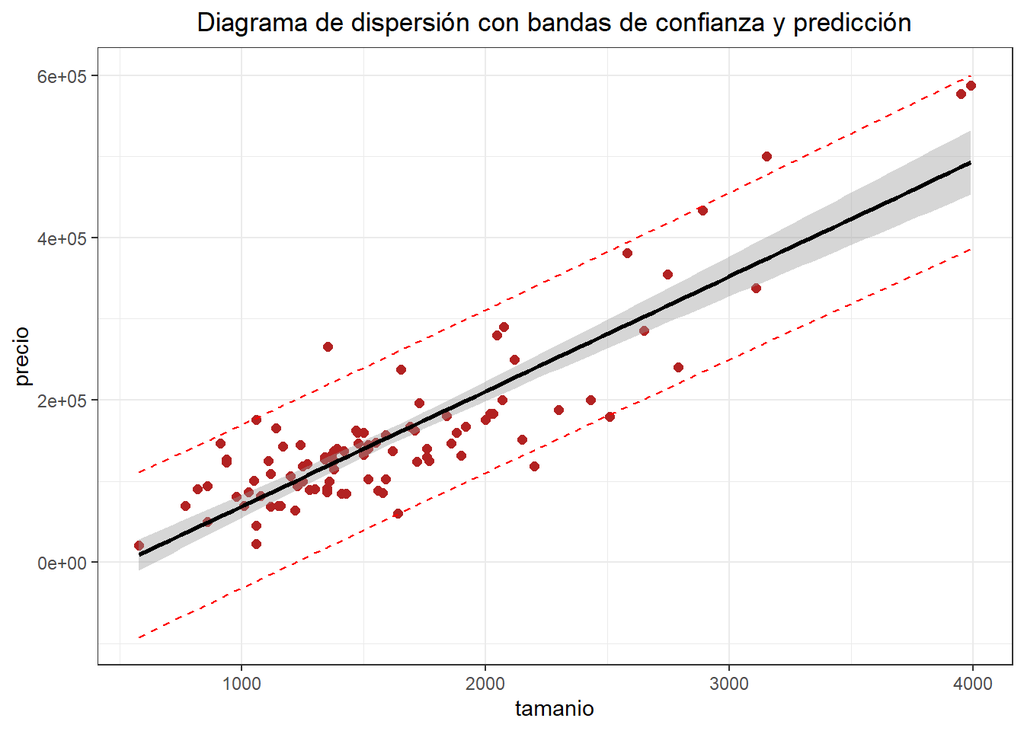

```r
tamanio=preciocasas_sin_obs64$tamanio
precio=preciocasas_sin_obs64$precio
graficaMLIntervalos(modeleje1p4,tamanio,precio,preciocasas_sin_obs64)
```

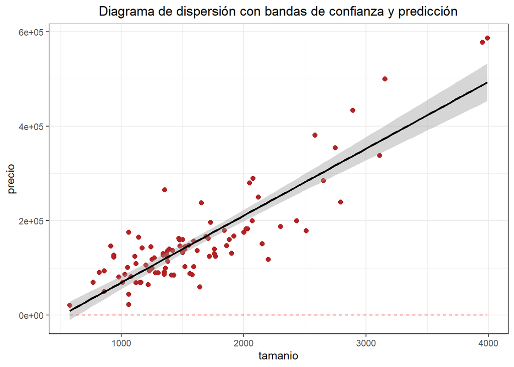

```r
graficaMLIntervalos(model5eje1,tamanio,precio,preciocasas)
```

## 5. Ajustar un modelo robusto y evaluar el promedio de los errores absolutos cometidos. Comparar con el mejor modelo lineal disponible.

```r
library(robustbase)
ajusterobP5 <- lmrob(precio ~ ., data = preciocasas)
summary(ajusterobP5)
```

```
##
## Call:
## lmrob(formula = precio ~ ., data = preciocasas)
##  \--> method = "MM"
## Residuals:
##     Min      1Q  Median      3Q     Max
## -145526  -21818   -2432   21716  192773
##
## Coefficients:
##              Estimate Std. Error t value Pr(>|t|)
## (Intercept)  33483.71   25497.74   1.313   0.1923
## caso          -234.26     159.11  -1.472   0.1443
## impuestos       31.31      13.23   2.366   0.0201 *
## dormitorios -14294.10   18187.25  -0.786   0.4339
## banios        6070.31    8119.23   0.748   0.4566
## estrena      24713.19   31441.79   0.786   0.4339
## tamanio         59.39      25.60   2.320   0.0225 *
## ---
## Signif. codes:  0 '***' 0.001 '**' 0.01 '*' 0.05 '.' 0.1 ' ' 1
##
## Robust residual standard error: 32070
## Multiple R-squared:  0.7604, Adjusted R-squared:  0.745
## Convergence in 46 IRWLS iterations
##
## Robustness weights:
##  3 observations c(6,9,35) are outliers with |weight| = 0 ( < 0.001);
##  5 weights are ~= 1. The remaining 92 ones are summarized as
##     Min.  1st Qu.   Median     Mean  3rd Qu.     Max.
## 0.003843 0.897900 0.956900 0.891200 0.985000 0.998900
## Algorithmic parameters:
##        tuning.chi                bb        tuning.psi        refine.tol
##         1.548e+00         5.000e-01         4.685e+00         1.000e-07
##           rel.tol         scale.tol         solve.tol       eps.outlier
##         1.000e-07         1.000e-10         1.000e-07         1.000e-03
##             eps.x warn.limit.reject warn.limit.meanrw
##         1.205e-08         5.000e-01         5.000e-01
##      nResample         max.it       best.r.s       k.fast.s          k.max
##            500             50              2              1            200
##    maxit.scale      trace.lev            mts     compute.rd fast.s.large.n
##            200              0           1000              0           2000
##                   psi           subsampling                   cov
##            "bisquare"         "nonsingular"         ".vcov.avar1"
## compute.outlier.stats
##                  "SM"
## seed : int(0)
```

Mejor modelo lineal basado en los errores

```r
#Promedios errores absolutos del modelo 1
m1<-summary(modeleje1)
print(paste("Modelo 1, errores: ", mean(abs(m1$residuals))))
```

```
## [1] "Modelo 1, errores:  39090.4333264768"
```

```r
#Promedios errores absolutos del modelo 2
m2<-summary(model2eje1)
print(paste("Modelo 2, errores: ", mean(abs(m2$residuals))))
```

```
## [1] "Modelo 2, errores:  2.72958461301243"
```

```r
#Promedios errores absolutos del modelo 3
m3<-summary(model3eje1)
print(paste("Modelo 3, errores: ", mean(abs(m3$residuals))))
```

```
## [1] "Modelo 3, errores:  0.113185750482932"
```

```r
#Promedios errores absolutos del modelo 4
m4<-summary(model4eje1)
print(paste("Modelo 4, errores: ", mean(abs(m4$residuals))))
```

```
## [1] "Modelo 4, errores:  46244.3522160805"
```

```r
#Promedios errores absolutos del modelo 5
m5<-summary(model5eje1)
print(paste("Modelo 5, errores: ", mean(abs(m5$residuals))))
```

```
## [1] "Modelo 5, errores:  0.113863496501512"
```

```r
#Promedios errores absolutos del modelo 6
m6<-summary(model2Box3eje1)
print(paste("Modelo 6, errores: ", mean(abs(m6$residuals))))
```

```
## [1] "Modelo 6, errores:  1.26087803637836e+27"
```

```r
#Promedios errores absolutos del modelo 7
m7<-summary(model2Box2eje1)
print(paste("Modelo 7, errores: ", mean(abs(m7$residuals))))
```

```
## [1] "Modelo 7, errores:  2.72958461301243"
```

```r
#Promedios errores absolutos del modelo 8
m8<-summary(model2Box22eje1)
print(paste("Modelo 8, errores: ", mean(abs(m8$residuals))))
```

```
## [1] "Modelo 8, errores:  0.113185750482932"
```

```r
#resumenCumplimiento(8,modeleje1,model2eje1,model3eje1,model4eje1,model5eje1,model2Box3eje1,model2Box2eje1,model2Box22eje1)
```

Función para obtener el error absoluto promedio de un modelo

```r
# Función para obtener el error absoluto promedio de un modelo
get_mean_absolute_error <- function(model) {
  #return(mean(abs(model$residuals)))
  residuals <- as.numeric(model$residuals)
  return(mean(abs(residuals)))
}
```

Conseguir el modelo con menor error absoluto medio

```r
# Crear un vector con los nombres de los modelos
model_names <- c("modeleje1", "model2eje1", "model3eje1", "model4eje1", "model5eje1", "model2Box3eje1", "model2Box2eje1", "model2Box22eje1")

errorModelos<-list(modeleje1,model2eje1,model3eje1,model4eje1,model5eje1,model2Box3eje1,model2Box2eje1,model2Box22eje1)

# Calcular los valores de error absoluto promedio para cada modelo en la lista errorModelos
mean_absolute_error_values <- sapply(errorModelos, get_mean_absolute_error)

# Obtener el índice del modelo con el menor valor de error absoluto promedio
min_index <- which.min(mean_absolute_error_values)

# Obtener el nombre del modelo con el menor valor de error absoluto promedio
best_model_name <- model_names[min_index]

# Obtener el valor del error absoluto promedio del mejor modelo
best_error <- mean_absolute_error_values[min_index]

# Imprimir el nombre del modelo y el valor del error absoluto promedio
cat("El modelo con el menor error absoluto promedio es", best_model_name, "con un error de", best_error, "\n")
```

```
## El modelo con el menor error absoluto promedio es model3eje1 con un error de 0.1131858
```

```r
# Imprimir el modelo con el menor valor de error absoluto promedio
cat("El modelo seria: \n")
```

```
## El modelo seria:
```

```r
print(errorModelos[min_index])
```

```
## [[1]]
##
## Call:
## lm(formula = log10(precio) ~ tamanio, data = preciocasas)
##
## Coefficients:
## (Intercept)      tamanio
##   4.6614258    0.0002826
```

El modelo con menor error es el modelo 3 con un error 0.113185750482932 y almacenado en la variable model3eje1.

```r
get_mean_absolute_error(ajusterobP5)
```

```
## [1] 31864.4
```

Se observa un mayor error promedio de los errores en el modelo robusto que en el lineal.

## 6. Utilizar un método de selección de variables para proponer un modelo multivariado. Analizar el cumplimiento de los supuestos.

```r
require(leaps)
mejores_modelos <- regsubsets(precio ~ ., data = preciocasas, nvmax = 5)
summary(mejores_modelos)
```

```
## Subset selection object
## Call: regsubsets.formula(precio ~ ., data = preciocasas, nvmax = 5)
## 6 Variables  (and intercept)
##             Forced in Forced out
## caso            FALSE      FALSE
## impuestos       FALSE      FALSE
## dormitorios     FALSE      FALSE
## banios          FALSE      FALSE
## estrena         FALSE      FALSE
## tamanio         FALSE      FALSE
## 1 subsets of each size up to 5
## Selection Algorithm: exhaustive
##          caso impuestos dormitorios banios estrena tamanio
## 1  ( 1 ) " "  "*"       " "         " "    " "     " "
## 2  ( 1 ) " "  "*"       " "         " "    " "     "*"
## 3  ( 1 ) " "  "*"       " "         " "    "*"     "*"
## 4  ( 1 ) "*"  "*"       " "         " "    "*"     "*"
## 5  ( 1 ) "*"  "*"       "*"         " "    "*"     "*"
```

```r
summary(mejores_modelos)$adjr2
```

```
## [1] 0.7059606 0.7674791 0.7830011 0.7948675 0.7963877
```

```r
# se identifica qué modelo tiene el valor máximo de R ajustado
which.max(summary(mejores_modelos)$adjr2)
```

```
## [1] 5
```

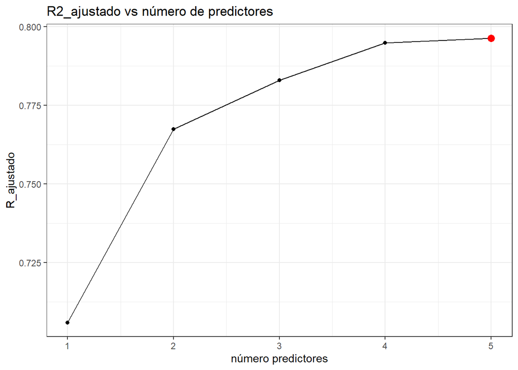

```r
library(ggplot2)
p <- ggplot(data = data.frame(n_predictores = 1:5, R_ajustado = summary(mejores_modelos)$adjr2), aes(x = n_predictores, y = R_ajustado)) +
  geom_line() +
  geom_point()
# Se identifica en rojo el máximo
p <- p + geom_point(aes(x=n_predictores[which.max(summary(mejores_modelos)$adjr2)], y=R_ajustado[which.max(summary(mejores_modelos)$adjr2)]), colour = "red", size = 3)
p <- p + scale_x_continuous(breaks = c(0:5)) + theme_bw() +
  labs(title = "R2_ajustado vs número de predictores", x = "número predictores")
p
```

```r
coef(object = mejores_modelos, id = 5)
```

```
##  (Intercept)         caso    impuestos  dormitorios      estrena      tamanio
##  26102.98704   -406.40201     37.92870 -11278.40695  44175.48062     65.27084
```

```r
mejores_modelos_backward <- regsubsets(precio ~ ., data = preciocasas, nvmax = 5, method = "backward")
# se identifica el valor máximo de R ajustado
which.max(summary(mejores_modelos_backward)$adjr2)
```

```
## [1] 5
```

```r
coef(object = mejores_modelos_backward, 5)
```

```
##  (Intercept)         caso    impuestos  dormitorios      estrena      tamanio
##  26102.98704   -406.40201     37.92870 -11278.40695  44175.48062     65.27084
```

```r
mejores_modelos_forward <- regsubsets(precio ~ ., data = preciocasas, nvmax = 5, method = "forward")
# se identifica el valor máximo de R ajustado
which.max(summary(mejores_modelos_forward)$adjr2)
```

```
## [1] 5
```

```r
coef(object = mejores_modelos_forward, 5)
```

```
##  (Intercept)         caso    impuestos  dormitorios      estrena      tamanio
##  26102.98704   -406.40201     37.92870 -11278.40695  44175.48062     65.27084
```

Todas las combinaciones de modelos

```r
library(olsrr)
lm.fit1 <- lm(precio ~ ., data = preciocasas)
k <- ols_step_all_possible(lm.fit1)

# AIC: Akaike Information Criteria
# SBIC: Sawa's Bayesian Information Criteria
# SBC: Schwarz Bayesian Criteria
# MSEP: Estimated error of prediction, assuming multivariate normality
# FPE: Final Prediction Error
# HSP: Hocking's Sp
# APC: Amemiya Prediction Criteria

k # OJO: en RStudio se ven menos columnas en la salida
```

|  | mindex | n | predictors | rsquare | adjr | predrsq | cp | aic | sbic | sbc | msep | fpe | apc | hsp |
| --- | --- | --- | --- | --- | --- | --- | --- | --- | --- | --- | --- | --- | --- | --- |
| 2 | 1 | 1 | impuestos | 0.70893073 | 0.7059606 | 0.687256734 | 44.059612 | 2470.457 | 2185.362 | 2478.273 | 301510262225 | 3075391993 | 0.3029497 | 31083404 |
| 6 | 2 | 1 | tamanio | 0.69519707 | 0.6920868 | 0.653152522 | 50.668107 | 2475.067 | 2189.804 | 2482.883 | 315736555709 | 3220499588 | 0.3172439 | 32550026 |
| 4 | 3 | 1 | banios | 0.31164675 | 0.3046227 | 0.263884158 | 235.228671 | 2556.531 | 2268.976 | 2564.347 | 713045268616 | 7273031748 | 0.7164493 | 73509518 |
| 5 | 4 | 1 | estrena | 0.22397578 | 0.2160572 | 0.166643020 | 277.415059 | 2568.519 | 2280.730 | 2576.335 | 803861091367 | 8199349320 | 0.8076987 | 82871936 |
| 3 | 5 | 1 | dormitorios | 0.15520214 | 0.1465817 | 0.099733671 | 310.508248 | 2577.011 | 2289.070 | 2584.826 | 875101729736 | 8926000835 | 0.8792794 | 90216301 |
| 1 | 6 | 1 | caso | 0.03617208 | 0.0263371 | -0.005872203 | 367.784318 | 2590.192 | 2302.036 | 2598.008 | 998401534034 | 10183653653 | 1.0031678 | 102927569 |
| 15 | 7 | 2 | impuestos tamanio | 0.77217647 | 0.7674791 | 0.731198662 | 15.626396 | 2447.958 | 2163.628 | 2458.379 | 238454113736 | 2455806210 | 0.2419157 | 24836228 |
| 14 | 8 | 2 | impuestos estrena | 0.73615890 | 0.7307189 | 0.691777002 | 32.957688 | 2462.636 | 2177.484 | 2473.056 | 276152313237 | 2844054795 | 0.2801612 | 28762690 |
| 7 | 9 | 2 | caso impuestos | 0.72427057 | 0.7185854 | 0.696560593 | 38.678231 | 2467.043 | 2181.656 | 2477.464 | 288595365376 | 2972204083 | 0.2927849 | 30058698 |
| 21 | 10 | 2 | estrena tamanio | 0.72259633 | 0.7168767 | 0.671081946 | 39.483859 | 2467.648 | 2182.230 | 2478.069 | 290347729175 | 2990251437 | 0.2945627 | 30241216 |

[output cut: 53 more lines]

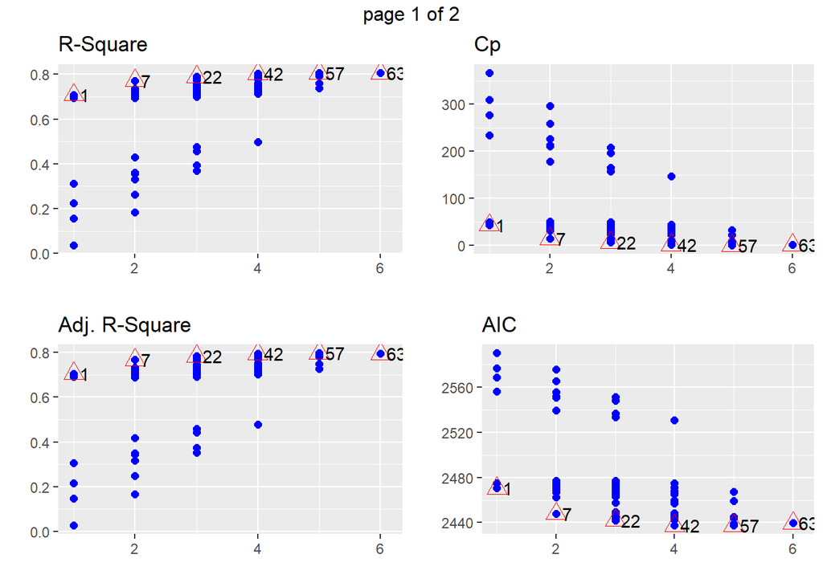

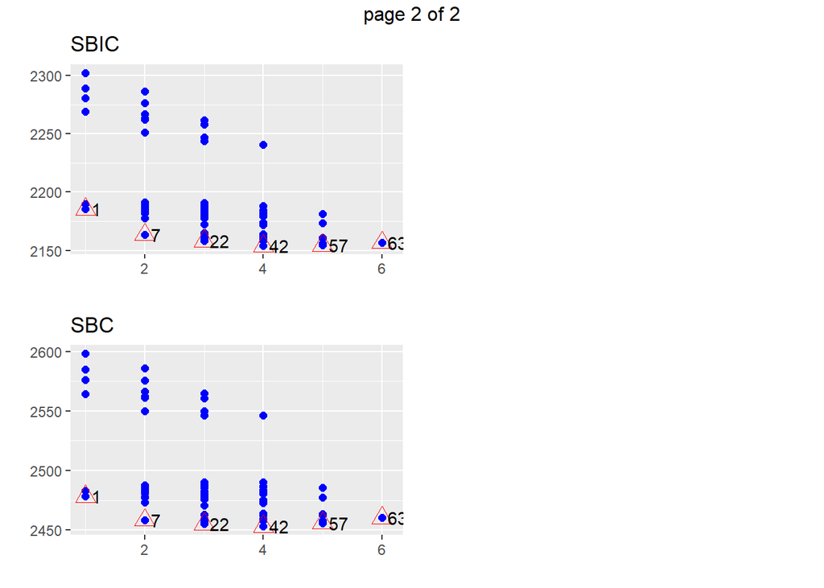

```r
plot(k)# el eje horizontal representa la cantidad de variables utilizadas en cada modelo.
```

```r
k_best <- ols_step_best_subset(lm.fit1)

# AIC: Akaike Information Criteria
# SBIC: Sawa's Bayesian Information Criteria
# SBC: Schwarz Bayesian Criteria
# MSEP: Estimated error of prediction, assuming multivariate normality
# FPE: Final Prediction Error
# HSP: Hocking's Sp
# APC: Amemiya Prediction Criteria

k_best
```

|  | mindex | n | predictors | rsquare | adjr | predrsq | cp | aic | sbic | sbc | msep | fpe | apc | hsp |
| --- | --- | --- | --- | --- | --- | --- | --- | --- | --- | --- | --- | --- | --- | --- |
| 2 | 1 | 1 | impuestos | 0.7089307 | 0.7059606 | 0.6872567 | 44.059612 | 2470.457 | 2185.362 | 2478.273 | 301510262225 | 3075391993 | 0.3029497 | 31083404 |
| 15 | 2 | 2 | impuestos tamanio | 0.7721765 | 0.7674791 | 0.7311987 | 15.626396 | 2447.958 | 2163.628 | 2458.379 | 238454113736 | 2455806210 | 0.2419157 | 24836228 |
| 37 | 3 | 3 | impuestos estrena tamanio | 0.7895768 | 0.7830011 | 0.7368706 | 9.253522 | 2442.013 | 2158.126 | 2455.039 | 222560172650 | 2314119125 | 0.2279584 | 23422258 |
| 47 | 4 | 4 | caso impuestos estrena tamanio | 0.8031556 | 0.7948675 | 0.7496088 | 4.719532 | 2437.342 | 2154.106 | 2452.973 | 210413016394 | 2208608301 | 0.2175648 | 22376984 |
| 59 | 5 | 5 | caso impuestos dormitorios estrena tamanio | 0.8066712 | 0.7963877 | 0.7340572 | 5.027895 | 2437.540 | 2154.641 | 2455.776 | 208877259459 | 2213118515 | 0.2180091 | 22449975 |
| 63 | 6 | 6 | caso impuestos dormitorios banios estrena tamanio | 0.8067291 | 0.7942600 | 0.7280398 | 7.000000 | 2439.510 | 2156.765 | 2460.351 | 211084350048 | 2257341379 | 0.2223654 | 22931140 |

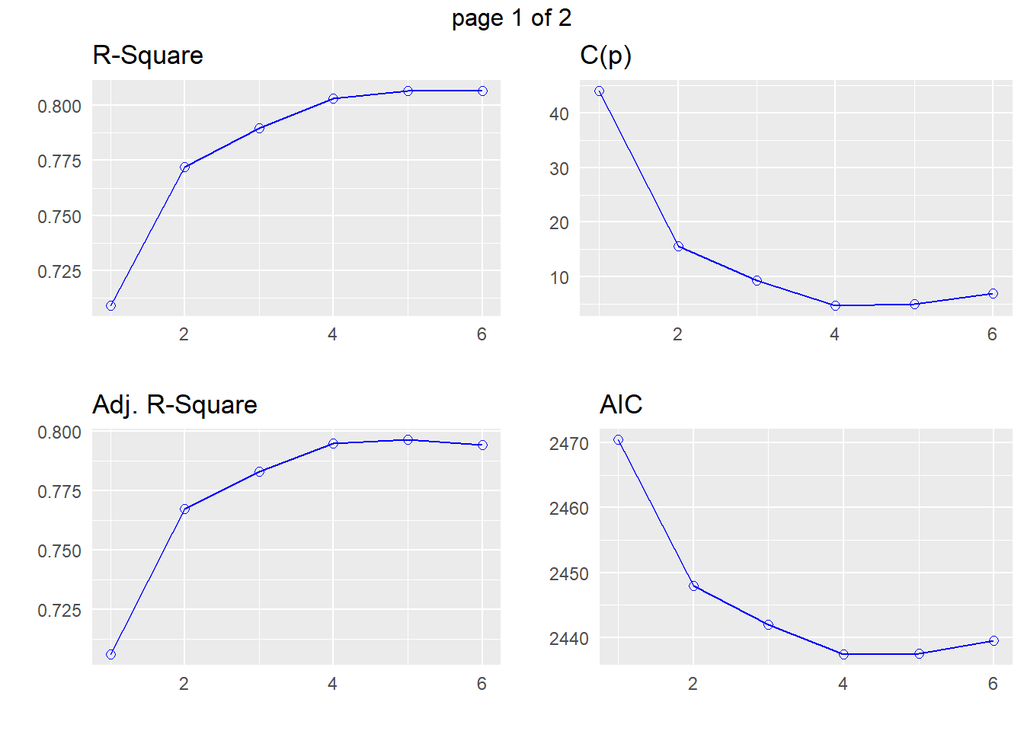

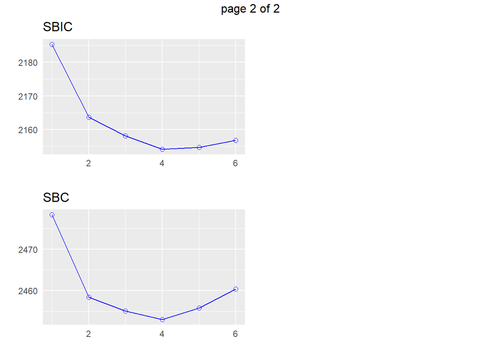

```r
plot(k_best)# el eje horizontal representa la cantidad de variables utilizadas en cada modelo.
```

```r
modeleje1P6= lm(precio ~ tamanio+caso+impuestos+estrena, data = preciocasas )
summary(modeleje1P6)
```

```
##
## Call:
## lm(formula = precio ~ tamanio + caso + impuestos + estrena, data = preciocasas)
##
## Residuals:
##     Min      1Q  Median      3Q     Max
## -154363  -24555    3416   23033  151703
##
## Coefficients:
##              Estimate Std. Error t value Pr(>|t|)
## (Intercept)  2665.488  15985.657   0.167  0.86793
## tamanio        59.538     12.182   4.887 4.14e-06 ***
## caso         -409.518    159.971  -2.560  0.01205 *
## impuestos      37.190      6.548   5.679 1.47e-07 ***
## estrena     48806.369  16030.861   3.045  0.00302 **
## ---
## Signif. codes:  0 '***' 0.001 '**' 0.01 '*' 0.05 '.' 0.1 ' ' 1
##
## Residual standard error: 45860 on 95 degrees of freedom
## Multiple R-squared:  0.8032, Adjusted R-squared:  0.7949
## F-statistic:  96.9 on 4 and 95 DF,  p-value: < 2.2e-16
```

```r
#modelo lineal simple con la selección de las mejores variables
cumplimientoSupuestos(modeleje1P6)
```

```
##      [,1]
## [1,] "Los residuos del modelo no son normales basado en el test de Shapiro"
## [2,] "En este caso, como el valor p ( 0.00317729738027902 ) es menor que el nivel de significancia (0.05), se tiene suficiente evidencia para rechazar la hipótesis nula de normalidad. Por lo tanto, se puede considerar que los residuos del modelo no siguen una distribución normal."
## [3,] "----------------------------------------------------------------------------------------------------"
## [4,] "Los errores del modelo no son homocedastico basado en el test de Breusch-Pagan"
## [5,] "En este caso, como el valor p ( 1.00922194346879e-07 ) es menor que el nivel de significancia establecido (0.05), se tiene suficiente evidencia para rechazar la hipótesis nula de homocedasticidad. Por lo tanto, se puede considerar que los errores del modelo no tienen varianzas constantes (h…
## [6,] "----------------------------------------------------------------------------------------------------"
## [7,] "Los errores del modelo no son independientes basado en el test de Durbin-Watson"
## [8,] "En este caso, como el valor p ( 0.0169306560800481 ) es menor que el nivel de significancia establecido (0.05), se tiene suficiente evidencia para rechazar la hipótesis nula de independencia de los errores. Por lo tanto, se puede concluir que existe autocorrelación en los errores del modelo…
```

```r
#modelo lineal simple transformado con la selección de las mejores variables
model2eje1P6= lm(log10(precio) ~ log10(tamanio+caso+impuestos+estrena), data = preciocasas )
summary(model2eje1P6)
```

```
##
## Call:
## lm(formula = log10(precio) ~ log10(tamanio + caso + impuestos +
##     estrena), data = preciocasas)
##
## Residuals:
##      Min       1Q   Median       3Q      Max
## -0.34401 -0.07762  0.00378  0.08288  0.30079
##
## Coefficients:
##                                             Estimate Std. Error t value
## (Intercept)                                   1.5537     0.2054   7.563
## log10(tamanio + caso + impuestos + estrena)   1.0178     0.0585  17.399
##                                             Pr(>|t|)
## (Intercept)                                 2.14e-11 ***
## log10(tamanio + caso + impuestos + estrena)  < 2e-16 ***
## ---
## Signif. codes:  0 '***' 0.001 '**' 0.01 '*' 0.05 '.' 0.1 ' ' 1
##
## Residual standard error: 0.1213 on 98 degrees of freedom
## Multiple R-squared:  0.7554, Adjusted R-squared:  0.7529
## F-statistic: 302.7 on 1 and 98 DF,  p-value: < 2.2e-16
```

```r
cumplimientoSupuestos(model2eje1P6)
```

```
##      [,1]
## [1,] "Los residuos del modelo son normales basado en el test de Shapiro"
## [2,] "En este caso, como el valor p ( 0.199654314728556 ) es mayor que el nivel de significancia (0.05), no se tiene suficiente evidencia para rechazar la hipótesis nula de normalidad. Por lo tanto, se puede considerar que los residuos del modelo siguen una distribución normal."
## [3,] "----------------------------------------------------------------------------------------------------"
## [4,] "Los errores del modelo son homocedastico basado en el test de Breusch-Pagan"
## [5,] "En este caso, como el valor p ( 0.730150777916259 ) es mayor que el nivel de significancia establecido (0.05), no se tiene suficiente evidencia para rechazar la hipótesis nula de homocedasticidad. Por lo tanto, se puede considerar que los errores del modelo tienen varianzas constantes (homo…
## [6,] "----------------------------------------------------------------------------------------------------"
## [7,] "Los errores del modelo no son independientes basado en el test de Durbin-Watson"
## [8,] "En este caso, como el valor p ( 0.0124299466441138 ) es menor que el nivel de significancia establecido (0.05), se tiene suficiente evidencia para rechazar la hipótesis nula de independencia de los errores. Por lo tanto, se puede concluir que existe autocorrelación en los errores del modelo…
```

```r
box_cox_resultP6 <- boxcox(precio ~ tamanio+caso+impuestos+estrena, lambda = -2:2, data = preciocasas)
```

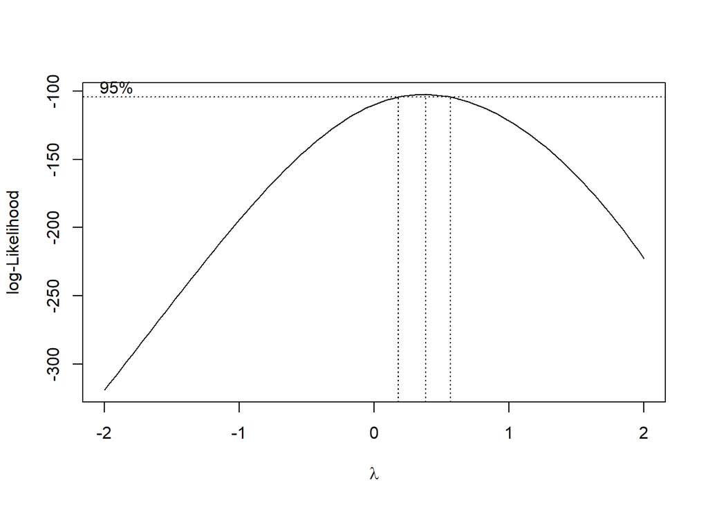

```r
# Se encuentra el valor óptimo de lambda que maximiza el logaritmo de verosimilitud
best_box_coxP6 <- box_cox_result$x[which.max(box_cox_result$y)]
best_box_coxP6
```

```
## [1] 0.3030303
```

```r
model2eje6P1 <- lm((precio)^(best_box_coxP6) ~ tamanio+caso+impuestos+estrena, data = preciocasas)

summary(model2eje6P1)
```

```
##
## Call:
## lm(formula = (precio)^(best_box_coxP6) ~ tamanio + caso + impuestos +
##     estrena, data = preciocasas)
##
## Residuals:
##     Min      1Q  Median      3Q     Max
## -8.8005 -2.2144  0.2241  2.1478  8.1094
##
## Coefficients:
##               Estimate Std. Error t value Pr(>|t|)
## (Intercept) 26.9587571  1.0453261  25.790  < 2e-16 ***
## tamanio      0.0031071  0.0007966   3.900 0.000179 ***
## caso        -0.0214905  0.0104608  -2.054 0.042685 *
## impuestos    0.0025916  0.0004282   6.052 2.83e-08 ***
## estrena      2.6042095  1.0482821   2.484 0.014733 *
## ---
## Signif. codes:  0 '***' 0.001 '**' 0.01 '*' 0.05 '.' 0.1 ' ' 1
##
## Residual standard error: 2.999 on 95 degrees of freedom
## Multiple R-squared:  0.7785, Adjusted R-squared:  0.7692
## F-statistic: 83.49 on 4 and 95 DF,  p-value: < 2.2e-16
```

```r
cumplimientoSupuestos(model2eje6P1)
```

```
##      [,1]
## [1,] "Los residuos del modelo no son normales basado en el test de Shapiro"
## [2,] "En este caso, como el valor p ( 0.0352683304901201 ) es menor que el nivel de significancia (0.05), se tiene suficiente evidencia para rechazar la hipótesis nula de normalidad. Por lo tanto, se puede considerar que los residuos del modelo no siguen una distribución normal."
## [3,] "----------------------------------------------------------------------------------------------------"
## [4,] "Los errores del modelo son homocedastico basado en el test de Breusch-Pagan"
## [5,] "En este caso, como el valor p ( 0.556404552250498 ) es mayor que el nivel de significancia establecido (0.05), no se tiene suficiente evidencia para rechazar la hipótesis nula de homocedasticidad. Por lo tanto, se puede considerar que los errores del modelo tienen varianzas constantes (homo…
## [6,] "----------------------------------------------------------------------------------------------------"
## [7,] "Los errores del modelo no son independientes basado en el test de Durbin-Watson"
## [8,] "En este caso, como el valor p ( 0.0216600262617641 ) es menor que el nivel de significancia establecido (0.05), se tiene suficiente evidencia para rechazar la hipótesis nula de independencia de los errores. Por lo tanto, se puede concluir que existe autocorrelación en los errores del modelo…
```

```r
model3eje6P1 <- lm((precio) ~ I((tamanio+caso+impuestos+estrena)^(best_box_coxP6)), data = preciocasas)

summary(model3eje6P1)
```

```
##
## Call:
## lm(formula = (precio) ~ I((tamanio + caso + impuestos + estrena)^(best_box_coxP6)),
##     data = preciocasas)
##
## Residuals:
##     Min      1Q  Median      3Q     Max
## -148937  -32348   -2472   25567  226518
##
## Coefficients:
##                                                            Estimate Std. Error
## (Intercept)                                                 -417104      40329
## I((tamanio + caso + impuestos + estrena)^(best_box_coxP6))    49075       3422
##                                                            t value Pr(>|t|)
## (Intercept)                                                 -10.34   <2e-16 ***
## I((tamanio + caso + impuestos + estrena)^(best_box_coxP6))   14.34   <2e-16 ***
## ---
## Signif. codes:  0 '***' 0.001 '**' 0.01 '*' 0.05 '.' 0.1 ' ' 1
##
## Residual standard error: 57820 on 98 degrees of freedom
## Multiple R-squared:  0.6773, Adjusted R-squared:  0.674
## F-statistic: 205.7 on 1 and 98 DF,  p-value: < 2.2e-16
```

```r
cumplimientoSupuestos(model3eje6P1)
```

```
##      [,1]
## [1,] "Los residuos del modelo no son normales basado en el test de Shapiro"
## [2,] "En este caso, como el valor p ( 7.47294546919588e-06 ) es menor que el nivel de significancia (0.05), se tiene suficiente evidencia para rechazar la hipótesis nula de normalidad. Por lo tanto, se puede considerar que los residuos del modelo no siguen una distribución normal."
## [3,] "----------------------------------------------------------------------------------------------------"
## [4,] "Los errores del modelo no son homocedastico basado en el test de Breusch-Pagan"
## [5,] "En este caso, como el valor p ( 3.24564874170103e-06 ) es menor que el nivel de significancia establecido (0.05), se tiene suficiente evidencia para rechazar la hipótesis nula de homocedasticidad. Por lo tanto, se puede considerar que los errores del modelo no tienen varianzas constantes (h…
## [6,] "----------------------------------------------------------------------------------------------------"
## [7,] "Los errores del modelo no son independientes basado en el test de Durbin-Watson"
## [8,] "En este caso, como el valor p ( 0.0234640887574373 ) es menor que el nivel de significancia establecido (0.05), se tiene suficiente evidencia para rechazar la hipótesis nula de independencia de los errores. Por lo tanto, se puede concluir que existe autocorrelación en los errores del modelo…
```

Se intenta con las variables de la selección de variables No. 43= impuestos dormitorios estrena tamanio

```r
model2eje1P6= lm(precio ~ impuestos+dormitorios+estrena+tamanio, data = preciocasas )
summary(model2eje1P6)
```

```
##
## Call:
## lm(formula = precio ~ impuestos + dormitorios + estrena + tamanio,
##     data = preciocasas)
##
## Residuals:
##     Min      1Q  Median      3Q     Max
## -182119  -23980   -1690   21492  163181
##
## Coefficients:
##               Estimate Std. Error t value Pr(>|t|)
## (Intercept)   2955.343  22827.885   0.129    0.897
## impuestos       37.991      6.735   5.641 1.74e-07 ***
## dormitorios -11607.319   8871.787  -1.308    0.194
## estrena      41626.816  16794.918   2.479    0.015 *
## tamanio         67.587     13.240   5.105 1.70e-06 ***
## ---
## Signif. codes:  0 '***' 0.001 '**' 0.01 '*' 0.05 '.' 0.1 ' ' 1
##
## Residual standard error: 47000 on 95 degrees of freedom
## Multiple R-squared:  0.7933, Adjusted R-squared:  0.7846
## F-statistic: 91.15 on 4 and 95 DF,  p-value: < 2.2e-16
```

Se retira la variable dormitorios por no ser significativa

```r
model2eje1P6= lm(precio ~ impuestos+estrena+tamanio, data = preciocasas )
summary(model2eje1P6)
```

```
##
## Call:
## lm(formula = precio ~ impuestos + estrena + tamanio, data = preciocasas)
##
## Residuals:
##     Min      1Q  Median      3Q     Max
## -165501  -25426    1449   20536  168747
##
## Coefficients:
##               Estimate Std. Error t value Pr(>|t|)
## (Intercept) -21353.776  13311.487  -1.604  0.11196
## impuestos       37.231      6.735   5.528 2.78e-07 ***
## estrena      46373.703  16459.019   2.818  0.00588 **
## tamanio         61.704     12.499   4.937 3.35e-06 ***
## ---
## Signif. codes:  0 '***' 0.001 '**' 0.01 '*' 0.05 '.' 0.1 ' ' 1
##
## Residual standard error: 47170 on 96 degrees of freedom
## Multiple R-squared:  0.7896, Adjusted R-squared:  0.783
## F-statistic: 120.1 on 3 and 96 DF,  p-value: < 2.2e-16
```

```r
cumplimientoSupuestos(model2eje1P6)
```

```
##      [,1]
## [1,] "Los residuos del modelo no son normales basado en el test de Shapiro"
## [2,] "En este caso, como el valor p ( 0.00138752386330549 ) es menor que el nivel de significancia (0.05), se tiene suficiente evidencia para rechazar la hipótesis nula de normalidad. Por lo tanto, se puede considerar que los residuos del modelo no siguen una distribución normal."
## [3,] "----------------------------------------------------------------------------------------------------"
## [4,] "Los errores del modelo no son homocedastico basado en el test de Breusch-Pagan"
## [5,] "En este caso, como el valor p ( 3.14874660823834e-08 ) es menor que el nivel de significancia establecido (0.05), se tiene suficiente evidencia para rechazar la hipótesis nula de homocedasticidad. Por lo tanto, se puede considerar que los errores del modelo no tienen varianzas constantes (h…
## [6,] "----------------------------------------------------------------------------------------------------"
## [7,] "Los errores del modelo no son independientes basado en el test de Durbin-Watson"
## [8,] "En este caso, como el valor p ( 0.0061634409362429 ) es menor que el nivel de significancia establecido (0.05), se tiene suficiente evidencia para rechazar la hipótesis nula de independencia de los errores. Por lo tanto, se puede concluir que existe autocorrelación en los errores del modelo…
```

```r
box_cox_result2P6 <- boxcox(precio ~ impuestos + estrena + tamanio, lambda = -2:2, data = preciocasas)
```

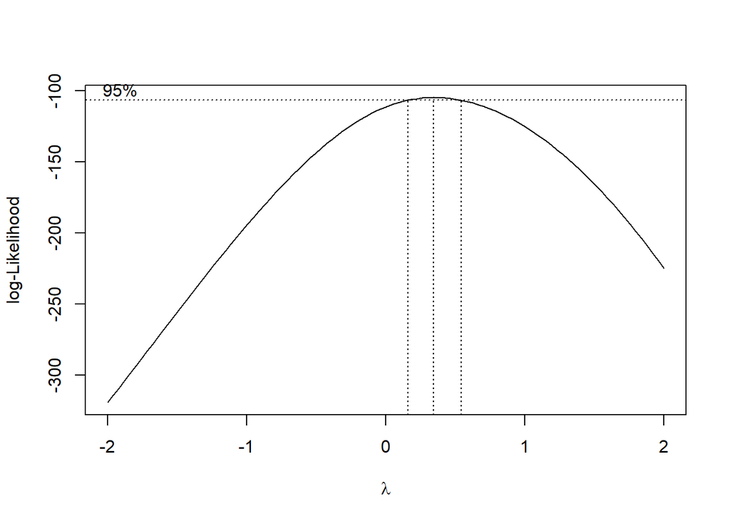

```r
# Se encuentra el valor óptimo de lambda que maximiza el logaritmo de verosimilitud
best_box_cox2P6 <- box_cox_result2P6$x[which.max(box_cox_result$y)]
best_box_cox2P6
```

```
## [1] 0.3030303
```

```r
model4eje6P1 <- lm((precio) ~ I((impuestos + estrena + tamanio)^(best_box_cox2P6)), data = preciocasas)

summary(model4eje6P1)
```

```
##
## Call:
## lm(formula = (precio) ~ I((impuestos + estrena + tamanio)^(best_box_cox2P6)),
##     data = preciocasas)
##
## Residuals:
##     Min      1Q  Median      3Q     Max
## -147344  -30730   -2552   22797  225362
##
## Coefficients:
##                                                      Estimate Std. Error
## (Intercept)                                           -406802      39608
## I((impuestos + estrena + tamanio)^(best_box_cox2P6))    48439       3376
##                                                      t value Pr(>|t|)
## (Intercept)                                           -10.27   <2e-16 ***
## I((impuestos + estrena + tamanio)^(best_box_cox2P6))   14.35   <2e-16 ***
## ---
## Signif. codes:  0 '***' 0.001 '**' 0.01 '*' 0.05 '.' 0.1 ' ' 1
##
## Residual standard error: 57810 on 98 degrees of freedom
## Multiple R-squared:  0.6774, Adjusted R-squared:  0.6741
## F-statistic: 205.8 on 1 and 98 DF,  p-value: < 2.2e-16
```

```r
cumplimientoSupuestos(model4eje6P1)
```

```
##      [,1]
## [1,] "Los residuos del modelo no son normales basado en el test de Shapiro"
## [2,] "En este caso, como el valor p ( 6.29035505391618e-06 ) es menor que el nivel de significancia (0.05), se tiene suficiente evidencia para rechazar la hipótesis nula de normalidad. Por lo tanto, se puede considerar que los residuos del modelo no siguen una distribución normal."
## [3,] "----------------------------------------------------------------------------------------------------"
## [4,] "Los errores del modelo no son homocedastico basado en el test de Breusch-Pagan"
## [5,] "En este caso, como el valor p ( 4.34983404888692e-06 ) es menor que el nivel de significancia establecido (0.05), se tiene suficiente evidencia para rechazar la hipótesis nula de homocedasticidad. Por lo tanto, se puede considerar que los errores del modelo no tienen varianzas constantes (h…
## [6,] "----------------------------------------------------------------------------------------------------"
## [7,] "Los errores del modelo no son independientes basado en el test de Durbin-Watson"
## [8,] "En este caso, como el valor p ( 0.0316660446704506 ) es menor que el nivel de significancia establecido (0.05), se tiene suficiente evidencia para rechazar la hipótesis nula de independencia de los errores. Por lo tanto, se puede concluir que existe autocorrelación en los errores del modelo…
```

Ninguno de los modelos lineales con selección de variables cumplen los supuestos. Se comparte resumen de los modelos utilizados:

```r
resumenCumplimiento(6,modeleje1P6, model2eje1P6, model2eje6P1, model3eje6P1, model2eje1P6, model4eje6P1)
```

```
##      [,1]           [,2]                [,3]
## [1,] "Modelos"      "Normalidad"        "Homocedasticidad"
## [2,] "modeleje1P6"  "No hay normalidad" "No hay homocedasticidad"
## [3,] "model2eje1P6" "No hay normalidad" "No hay homocedasticidad"
## [4,] "model2eje6P1" "No hay normalidad" "Hay homocedasticidad"
## [5,] "model3eje6P1" "No hay normalidad" "No hay homocedasticidad"
## [6,] "model2eje1P6" "No hay normalidad" "No hay homocedasticidad"
## [7,] "model4eje6P1" "No hay normalidad" "No hay homocedasticidad"
##      [,4]                   [,5]
## [1,] "Independencia"        "Cumplimiento"
## [2,] "No hay independencia" "No"
## [3,] "No hay independencia" "No"
## [4,] "No hay independencia" "No"
## [5,] "No hay independencia" "No"
## [6,] "No hay independencia" "No"
## [7,] "No hay independencia" "No"
```

```r
#modelo lineal robusto con la seleccion de las mejores variables
ajusterobP6 <- lmrob(precio ~ tamanio+caso+impuestos+estrena, data = preciocasas)
summary(ajusterobP6)
```

```
##
## Call:
## lmrob(formula = precio ~ tamanio + caso + impuestos + estrena, data = preciocasas)
##  \--> method = "MM"
## Residuals:
##    Min     1Q Median     3Q    Max
## -89017 -18444   -280  24385 209157
##
## Coefficients:
##              Estimate Std. Error t value Pr(>|t|)
## (Intercept) 33626.992  25195.001   1.335  0.18517
## tamanio        40.625     16.749   2.426  0.01717 *
## caso         -293.024    150.972  -1.941  0.05523 .
## impuestos      29.838      8.844   3.374  0.00107 **
## estrena     41359.032  25790.427   1.604  0.11211
## ---
## Signif. codes:  0 '***' 0.001 '**' 0.01 '*' 0.05 '.' 0.1 ' ' 1
##
## Robust residual standard error: 32600
## Multiple R-squared:  0.7332, Adjusted R-squared:  0.722
## Convergence in 27 IRWLS iterations
##
## Robustness weights:
##  3 observations c(6,9,35) are outliers with |weight| = 0 ( < 0.001);
##  7 weights are ~= 1. The remaining 90 ones are summarized as
##    Min. 1st Qu.  Median    Mean 3rd Qu.    Max.
## 0.01583 0.89390 0.95350 0.88990 0.98420 0.99860
## Algorithmic parameters:
##        tuning.chi                bb        tuning.psi        refine.tol
##         1.548e+00         5.000e-01         4.685e+00         1.000e-07
##           rel.tol         scale.tol         solve.tol       eps.outlier
##         1.000e-07         1.000e-10         1.000e-07         1.000e-03
##             eps.x warn.limit.reject warn.limit.meanrw
##         1.205e-08         5.000e-01         5.000e-01
##      nResample         max.it       best.r.s       k.fast.s          k.max
##            500             50              2              1            200
##    maxit.scale      trace.lev            mts     compute.rd fast.s.large.n
##            200              0           1000              0           2000
##                   psi           subsampling                   cov
##            "bisquare"         "nonsingular"         ".vcov.avar1"
## compute.outlier.stats
##                  "SM"
## seed : int(0)
```

```r
get_mean_absolute_error(ajusterobP6)
```

```
## [1] 32908.53
```

```r
evaluarErrores_modelos <- function(modelos) {
  # Crear un vector con los nombres de los modelos
  model_names <- names(modelos)

  # Calcular los valores de error absoluto promedio para cada modelo en la lista de modelos
  mean_absolute_error_values <- sapply(modelos, get_mean_absolute_error)

  # Obtener el índice del modelo con el menor valor de error absoluto promedio
  min_index <- which.min(mean_absolute_error_values)

  if (min_index > 0) {
    # Obtener el nombre del modelo con el menor valor de error absoluto promedio
    best_model_name <- model_names[min_index]

    # Obtener el valor del error absoluto promedio del mejor modelo
    best_error <- mean_absolute_error_values[min_index]

    # Imprimir el nombre del modelo y el valor del error absoluto promedio
    cat("El modelo con el menor error absoluto promedio es", best_model_name, "con un error de", best_error, "\n")

    # Imprimir el modelo con el menor valor de error absoluto promedio
    cat("El modelo sería:\n")
    print(modelos[[min_index]])
  } else {
    cat("No se pudo determinar el mejor modelo debido a un error en los nombres de los modelos.\n")
  }
}
```

```r
# Ejemplo de uso:
modelosP6 <- list(
  modeleje1P6 = modeleje1P6,
  model2eje1P6 = model2eje1P6,
  model2eje6P1 = model2eje6P1,
  model3eje6P1 = model3eje6P1,
  model2eje1P6 = model2eje1P6,
  model4eje6P1 = model4eje6P1)

evaluarErrores_modelos(modelosP6)
```

```
## El modelo con el menor error absoluto promedio es model2eje6P1 con un error de 2.334749
## El modelo sería:
##
## Call:
## lm(formula = (precio)^(best_box_coxP6) ~ tamanio + caso + impuestos +
##     estrena, data = preciocasas)
##
## Coefficients:
## (Intercept)      tamanio         caso    impuestos      estrena
##   26.958757     0.003107    -0.021490     0.002592     2.604210
```

Se observa que el mejor modelo lineal tiene un error absoluto promedio de 2.334749 a diferencia del modelo robusto con 32908.53. Como ninguno de los modelos presenta una representación de los datos si se sugiere usar GAMLSS, poruqe puede existir variables no linales que afectan los modelos utilizados hasta ahora.

## 7. Le parece adecuado un modelo GAMLSS en este caso? Justifique.

```r
mod_OLS <- gamlss( formula = precio ~ pb(tamanio)+caso+impuestos+estrena, family = NO, data = preciocasas, trace = FALSE)
summary(mod_OLS)
```

```
## Family:  c("NO", "Normal")
##
## Call:  gamlss(formula = precio ~ pb(tamanio) + caso + impuestos +
##     estrena, family = NO, data = preciocasas, trace = FALSE)
##
## Fitting method: RS()
##
## ------------------------------------------------------------------
## Mu link function:  identity
## Mu Coefficients:
##              Estimate Std. Error t value Pr(>|t|)
## (Intercept)  1203.215  18055.469   0.067  0.94701
## pb(tamanio)    60.729     12.488   4.863 4.70e-06 ***
## caso         -393.013    162.929  -2.412  0.01782 *
## impuestos      36.550      6.267   5.832 7.91e-08 ***
## estrena     47994.593  15336.864   3.129  0.00234 **
## ---
## Signif. codes:  0 '***' 0.001 '**' 0.01 '*' 0.05 '.' 0.1 ' ' 1
##
## ------------------------------------------------------------------
## Sigma link function:  log
## Sigma Coefficients:
##             Estimate Std. Error t value Pr(>|t|)
## (Intercept) 10.68216    0.07071   151.1   <2e-16 ***
## ---
## Signif. codes:  0 '***' 0.001 '**' 0.01 '*' 0.05 '.' 0.1 ' ' 1
##
## ------------------------------------------------------------------
## NOTE: Additive smoothing terms exist in the formulas:
##  i) Std. Error for smoothers are for the linear effect only.
## ii) Std. Error for the linear terms maybe are not accurate.
## ------------------------------------------------------------------
## No. of observations in the fit:  100
## Degrees of Freedom for the fit:  7.097952
##       Residual Deg. of Freedom:  92.90205
##                       at cycle:  4
##
## Global Deviance:     2420.22
##             AIC:     2434.416
##             SBC:     2452.907
```

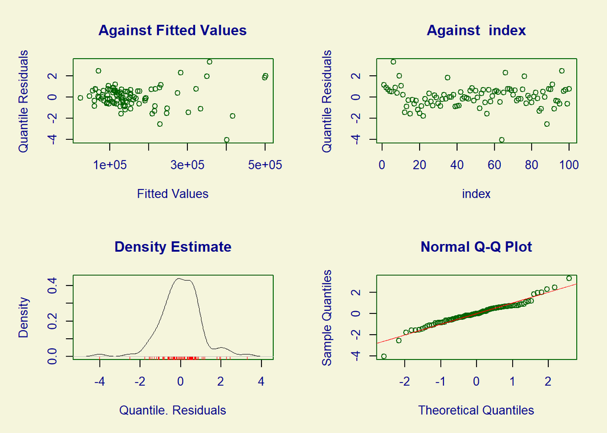

```
##        Summary of the Quantile Residuals
##                            mean   =  2.115093e-14
##                        variance   =  1.010101
##                coef. of skewness  =  -0.2141252
##                coef. of kurtosis  =  5.696845
## Filliben correlation coefficient  =  0.9732235
```

```r
plot(mod_OLS)
```

```r
cumplimientoSupuestos(mod_OLS)
```

```
##      [,1]
## [1,] "Los residuos del modelo no son normales basado en el test de Shapiro"
## [2,] "En este caso, como el valor p ( 0.00146430169252583 ) es menor que el nivel de significancia (0.05), se tiene suficiente evidencia para rechazar la hipótesis nula de normalidad. Por lo tanto, se puede considerar que los residuos del modelo no siguen una distribución normal."
## [3,] "----------------------------------------------------------------------------------------------------"
## [4,] "Los errores del modelo no son homocedastico basado en el test de Breusch-Pagan"
## [5,] "En este caso, como el valor p ( 1.00922194346879e-07 ) es menor que el nivel de significancia establecido (0.05), se tiene suficiente evidencia para rechazar la hipótesis nula de homocedasticidad. Por lo tanto, se puede considerar que los errores del modelo no tienen varianzas constantes (h…
## [6,] "----------------------------------------------------------------------------------------------------"
## [7,] "Los errores del modelo no son independientes basado en el test de Durbin-Watson"
## [8,] "En este caso, como el valor p ( 0.0169306560800481 ) es menor que el nivel de significancia establecido (0.05), se tiene suficiente evidencia para rechazar la hipótesis nula de independencia de los errores. Por lo tanto, se puede concluir que existe autocorrelación en los errores del modelo…
```

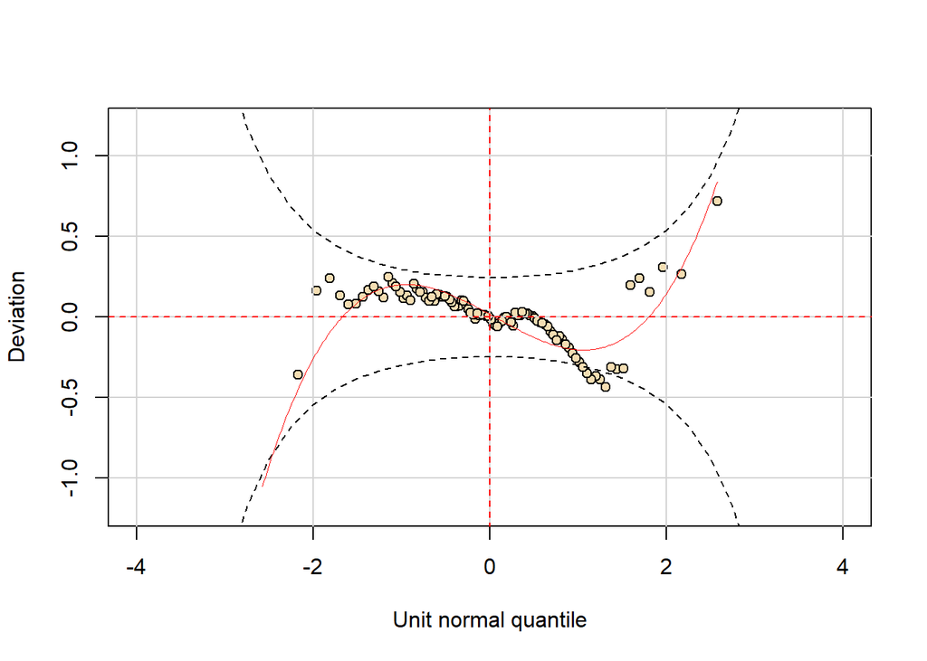

```r
wp(mod_OLS)
```

```r
mod_GAMLSS <- gamlss(formula = precio ~ pb(tamanio)+caso+impuestos+estrena, sigma.formula = ~ pb(tamanio)+caso+impuestos+estrena, family = GA, data = preciocasas, trace = FALSE )
summary(mod_GAMLSS)
```

```
## Family:  c("GA", "Gamma")
##
## Call:  gamlss(formula = precio ~ pb(tamanio) + caso + impuestos +
##     estrena, sigma.formula = ~pb(tamanio) + caso +
##     impuestos + estrena, family = GA, data = preciocasas,      trace = FALSE)
##
## Fitting method: RS()
##
## ------------------------------------------------------------------
## Mu link function:  log
## Mu Coefficients:
##               Estimate Std. Error t value Pr(>|t|)
## (Intercept)  1.110e+01  9.005e-02 123.280  < 2e-16 ***
## pb(tamanio)  2.486e-04  7.059e-05   3.522 0.000685 ***
## caso        -2.162e-03  8.405e-04  -2.573 0.011785 *
## impuestos    2.179e-04  3.548e-05   6.142 2.35e-08 ***
## estrena      1.780e-01  8.999e-02   1.978 0.051041 .
## ---
## Signif. codes:  0 '***' 0.001 '**' 0.01 '*' 0.05 '.' 0.1 ' ' 1
##
## ------------------------------------------------------------------
## Sigma link function:  log
## Sigma Coefficients:
##               Estimate Std. Error t value Pr(>|t|)
## (Intercept) -1.288e+00  2.781e-01  -4.630 1.27e-05 ***
## pb(tamanio)  4.819e-05  2.492e-04   0.193    0.847
## caso         2.119e-03  2.351e-03   0.901    0.370
## impuestos   -1.407e-04  1.113e-04  -1.264    0.210
## estrena      1.668e-02  3.227e-01   0.052    0.959
## ---
## Signif. codes:  0 '***' 0.001 '**' 0.01 '*' 0.05 '.' 0.1 ' ' 1
##
## ------------------------------------------------------------------
## NOTE: Additive smoothing terms exist in the formulas:
##  i) Std. Error for smoothers are for the linear effect only.
## ii) Std. Error for the linear terms maybe are not accurate.
## ------------------------------------------------------------------
## No. of observations in the fit:  100
## Degrees of Freedom for the fit:  12.77804
##       Residual Deg. of Freedom:  87.22196
##                       at cycle:  5
##
## Global Deviance:     2370.945
##             AIC:     2396.501
##             SBC:     2429.79
```

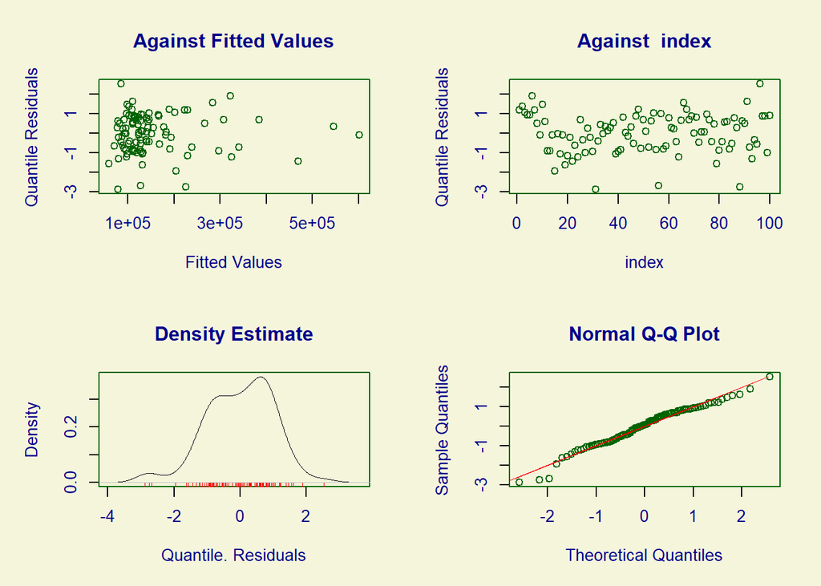

```
##        Summary of the Quantile Residuals
##                            mean   =  -0.005061181
##                        variance   =  1.006367
##                coef. of skewness  =  -0.4219322
##                coef. of kurtosis  =  3.231297
## Filliben correlation coefficient  =  0.9885076
```

```r
plot(mod_GAMLSS)
```

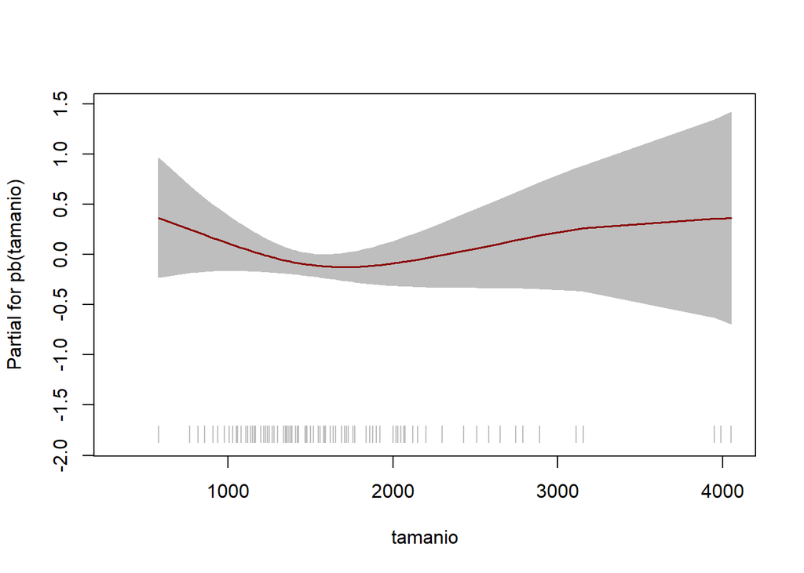

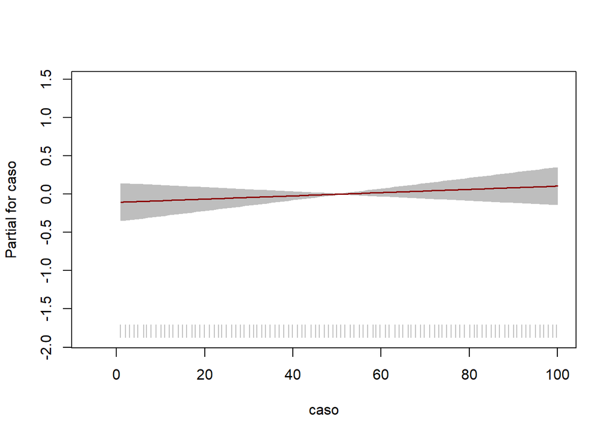

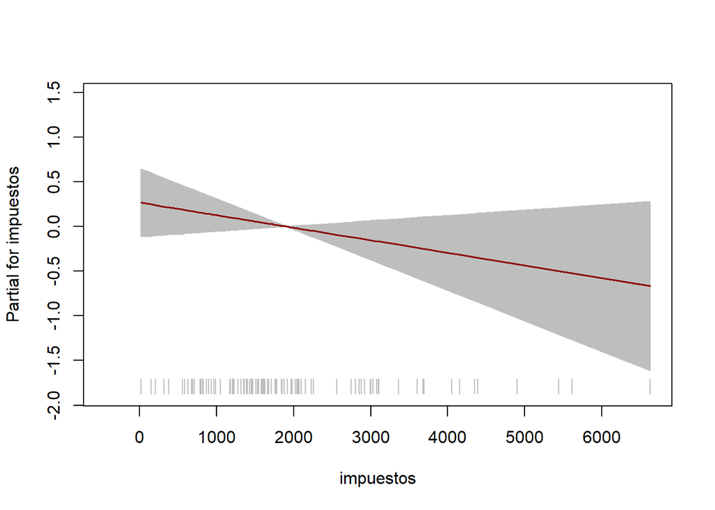

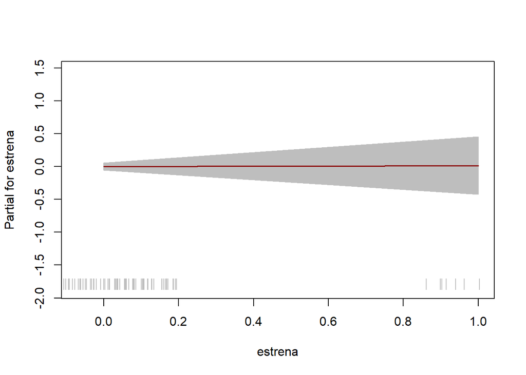

```r
# Efecto individuales de los Predictores (GAMLSS)
term.plot(mod_GAMLSS, parameter = 'sigma',ask = FALSE, rug = TRUE)
```